# Living Conditions and Dropout (step 2)

# Survival Analyses (Feb 2023)

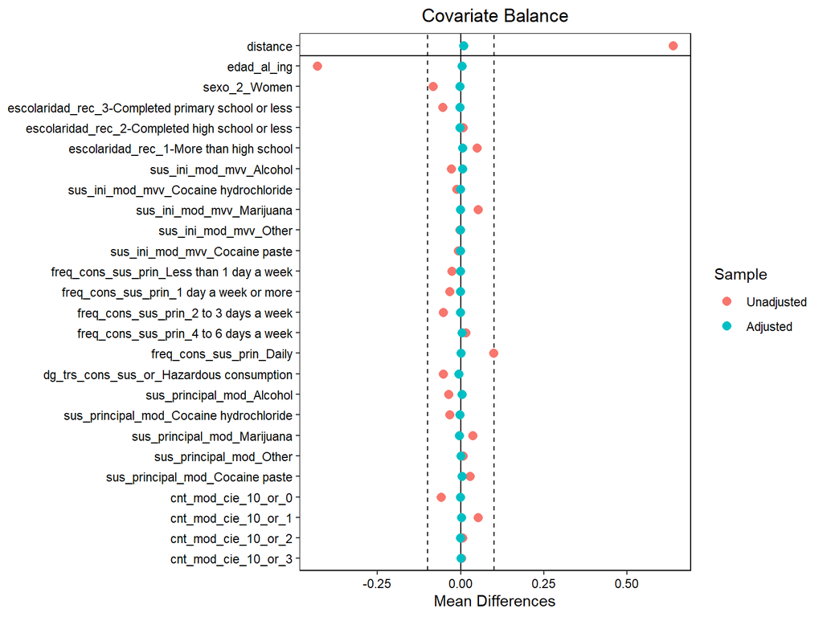

```r
require(timereg)

require(MatchIt)
vars_cov<-c("edad_al_ing_sc", "sexo_2", "escolaridad_rec", "sus_ini_mod_mvv", "freq_cons_sus_prin", "dg_trs_cons_sus_or", "sus_principal_mod")

prueba2_imp22$edad_al_ing_sc<-scale(prueba2_imp22$edad_al_ing, scale=F)
prueba2_imp22$edad_al_ing_sc<-as.numeric(prueba2_imp22$edad_al_ing_sc)

m.out1 <- matchit(con_quien_vive_joel_fam_or ~ edad_al_ing + sexo_2+escolaridad_rec+sus_ini_mod_mvv+freq_cons_sus_prin+dg_trs_cons_sus_or+sus_principal_mod+cnt_mod_cie_10_or,
                  data = prueba2_imp22 %>% dplyr::filter(con_quien_vive_joel_alone!=1),
                  method = "nearest",
                  discard = "both",
                  caliper = .01,
                  standardize = T)

plot(
cobalt::bal.tab(m.out1, un = TRUE, m.threshold = .1,
        v.threshold = 2))
```

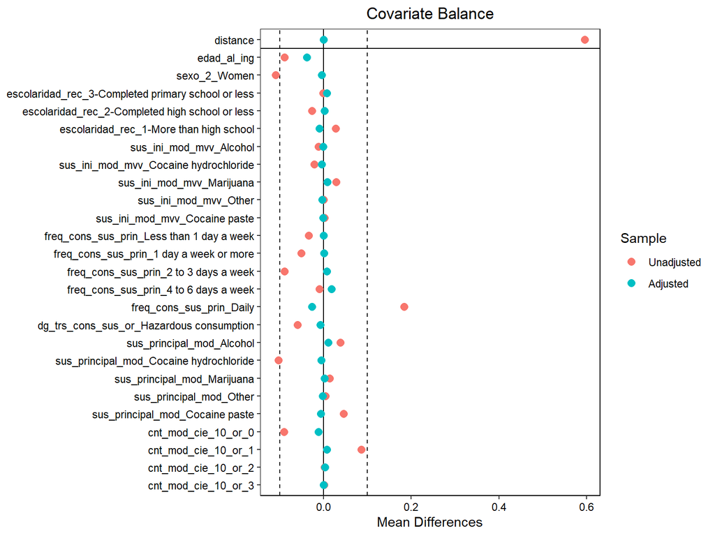

```r
m.out2 <- matchit(con_quien_vive_joel_alone ~ edad_al_ing+ sexo_2+escolaridad_rec+sus_ini_mod_mvv+freq_cons_sus_prin+dg_trs_cons_sus_or+sus_principal_mod+cnt_mod_cie_10_or,
                  data = prueba2_imp22 %>% dplyr::filter(con_quien_vive_joel_fam_or!=1),
                  method = "nearest",
                  discard = "both",
                  caliper = .01,
                  standardize = T)

plot(
cobalt::bal.tab(m.out2, un = TRUE, m.threshold = .1,
        v.threshold = 2))
```

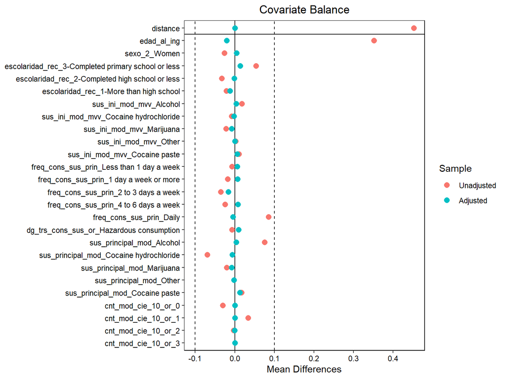

```r
m.out3 <- matchit(con_quien_vive_joel_alone ~ edad_al_ing + sexo_2+escolaridad_rec+sus_ini_mod_mvv+freq_cons_sus_prin+dg_trs_cons_sus_or+sus_principal_mod+cnt_mod_cie_10_or,
                  data = prueba2_imp22 %>% dplyr::filter(con_quien_vive_joel_coup_chil!=1),
                  method = "nearest",
                  discard = "both",
                  caliper = .01,
                  standardize = T)

plot(
cobalt::bal.tab(m.out3, un = TRUE, m.threshold = .1,
        v.threshold = 2))
```

```r
fam_or_vs_couple_child<-match.data(m.out1)
alone_vs_couple_child<-match.data(m.out2)
alone_vs_fam_orig<-match.data(m.out3)

sub1_statadf_miss<- dplyr::mutate(fam_or_vs_couple_child, yrs_to_tr_dropout= dplyr::case_when(yrs_to_tr_dropout==0~0.0001,T~yrs_to_tr_dropout)) %>%
  #dplyr::mutate(con_quien_vive_joel_rec= ifelse(con_quien_vive_joel=="Alone",1,0)) %>%
  slice(1:5e5) %>%
  data.table::data.table()

sub2_statadf_miss<- dplyr::mutate(alone_vs_couple_child, yrs_to_tr_dropout= dplyr::case_when(yrs_to_tr_dropout==0~0.0001,T~yrs_to_tr_dropout)) %>%
  #dplyr::mutate(con_quien_vive_joel_rec= ifelse(con_quien_vive_joel=="Alone",1,0)) %>%
  slice(1:5e5) %>%
  data.table::data.table()

sub3_statadf_miss<- dplyr::mutate(alone_vs_fam_orig, yrs_to_tr_dropout= dplyr::case_when(yrs_to_tr_dropout==0~0.0001,T~yrs_to_tr_dropout)) %>%
  #dplyr::mutate(con_quien_vive_joel_rec= ifelse(con_quien_vive_joel=="Alone",1,0)) %>%
  slice(1:5e5) %>%
  data.table::data.table()


cat("Living with Family of origin vs. With couple/children at 6 months")
```

```
Living with Family of origin vs. With couple/children at 6 months
```

```r
survRM2::rmst2(sub1_statadf_miss$yrs_to_tr_dropout, sub1_statadf_miss$event, as.numeric(sub1_statadf_miss$con_quien_vive_joel=="Family of origin"), tau=.5)
```

```
The truncation time: tau = 0.5  was specified.

Restricted Mean Survival Time (RMST) by arm
              Est.    se lower .95 upper .95
RMST (arm=1) 0.394 0.002     0.390     0.397
RMST (arm=0) 0.384 0.002     0.381     0.388


Restricted Mean Time Lost (RMTL) by arm
              Est.    se lower .95 upper .95
RMTL (arm=1) 0.106 0.002     0.103     0.110
RMTL (arm=0) 0.116 0.002     0.112     0.119


Between-group contrast
                      Est. lower .95 upper .95 p
RMST (arm=1)-(arm=0) 0.010     0.005     0.014 0
RMST (arm=1)/(arm=0) 1.025     1.012     1.037 0
RMTL (arm=1)/(arm=0) 0.918     0.879     0.958 0
```

```r
cat("Living with Family of origin vs. With couple/children at 1 year")
```

```
Living with Family of origin vs. With couple/children at 1 year
```

```r
survRM2::rmst2(sub1_statadf_miss$yrs_to_tr_dropout, sub1_statadf_miss$event, as.numeric(sub1_statadf_miss$con_quien_vive_joel=="Family of origin"), tau=1)
```

```
The truncation time: tau = 1  was specified.

Restricted Mean Survival Time (RMST) by arm
              Est.    se lower .95 upper .95
RMST (arm=1) 0.608 0.004      0.60     0.616
RMST (arm=0) 0.578 0.004      0.57     0.587


Restricted Mean Time Lost (RMTL) by arm
              Est.    se lower .95 upper .95
RMTL (arm=1) 0.392 0.004     0.384      0.40
RMTL (arm=0) 0.422 0.004     0.413      0.43


Between-group contrast
                      Est. lower .95 upper .95 p
RMST (arm=1)-(arm=0) 0.030     0.018     0.041 0
RMST (arm=1)/(arm=0) 1.051     1.031     1.072 0
RMTL (arm=1)/(arm=0) 0.930     0.903     0.957 0
```

```r
cat("Living with Family of origin vs. With couple/children at 3 years")
```

```
Living with Family of origin vs. With couple/children at 3 years
```

```r
survRM2::rmst2(sub1_statadf_miss$yrs_to_tr_dropout, sub1_statadf_miss$event, as.numeric(sub1_statadf_miss$con_quien_vive_joel=="Family of origin"), tau=3)
```

```
The truncation time: tau = 3  was specified.

Restricted Mean Survival Time (RMST) by arm
              Est.    se lower .95 upper .95
RMST (arm=1) 1.248 0.015     1.218     1.277
RMST (arm=0) 1.127 0.014     1.099     1.155


Restricted Mean Time Lost (RMTL) by arm
              Est.    se lower .95 upper .95
RMTL (arm=1) 1.752 0.015     1.723     1.782
RMTL (arm=0) 1.873 0.014     1.845     1.901


Between-group contrast
                      Est. lower .95 upper .95 p
RMST (arm=1)-(arm=0) 0.120     0.080     0.161 0
RMST (arm=1)/(arm=0) 1.107     1.069     1.145 0
RMTL (arm=1)/(arm=0) 0.936     0.915     0.957 0
```

```r
cat("===============================================================================")
cat("Living Alone vs. Family of origin at 6 months")
```

```
Living Alone vs. Family of origin at 6 months
```

```r
survRM2::rmst2(sub3_statadf_miss$yrs_to_tr_dropout, sub3_statadf_miss$event, sub3_statadf_miss$con_quien_vive_joel_alone, tau=.5)
```

```
The truncation time: tau = 0.5  was specified.

Restricted Mean Survival Time (RMST) by arm
              Est.    se lower .95 upper .95
RMST (arm=1) 0.358 0.004     0.350     0.367
RMST (arm=0) 0.385 0.004     0.377     0.393


Restricted Mean Time Lost (RMTL) by arm
              Est.    se lower .95 upper .95
RMTL (arm=1) 0.142 0.004     0.133     0.150
RMTL (arm=0) 0.115 0.004     0.107     0.123


Between-group contrast
                       Est. lower .95 upper .95 p
RMST (arm=1)-(arm=0) -0.027    -0.039    -0.015 0
RMST (arm=1)/(arm=0)  0.930     0.901     0.960 0
RMTL (arm=1)/(arm=0)  1.235     1.126     1.355 0
```

```r
cat("Living Alone vs. Family of origin at 1 year")
```

```
Living Alone vs. Family of origin at 1 year
```

```r
survRM2::rmst2(sub3_statadf_miss$yrs_to_tr_dropout, sub3_statadf_miss$event, sub3_statadf_miss$con_quien_vive_joel_alone, tau=1)
```

```
The truncation time: tau = 1  was specified.

Restricted Mean Survival Time (RMST) by arm
              Est.   se lower .95 upper .95
RMST (arm=1) 0.544 0.01     0.524     0.563
RMST (arm=0) 0.598 0.01     0.578     0.617


Restricted Mean Time Lost (RMTL) by arm
              Est.   se lower .95 upper .95
RMTL (arm=1) 0.456 0.01     0.437     0.476
RMTL (arm=0) 0.402 0.01     0.383     0.422


Between-group contrast
                       Est. lower .95 upper .95 p
RMST (arm=1)-(arm=0) -0.054    -0.081    -0.026 0
RMST (arm=1)/(arm=0)  0.910     0.867     0.955 0
RMTL (arm=1)/(arm=0)  1.134     1.063     1.209 0
```

```r
cat("Living Alone vs. Family of origin at 3 years")
```

```
Living Alone vs. Family of origin at 3 years
```

```r
survRM2::rmst2(sub3_statadf_miss$yrs_to_tr_dropout, sub3_statadf_miss$event, sub3_statadf_miss$con_quien_vive_joel_alone, tau=3)
```

```
The truncation time: tau = 3  was specified.

Restricted Mean Survival Time (RMST) by arm
              Est.    se lower .95 upper .95
RMST (arm=1) 1.116 0.034     1.050     1.182
RMST (arm=0) 1.264 0.035     1.196     1.332


Restricted Mean Time Lost (RMTL) by arm
              Est.    se lower .95 upper .95
RMTL (arm=1) 1.884 0.034     1.818     1.950
RMTL (arm=0) 1.736 0.035     1.668     1.804


Between-group contrast
                       Est. lower .95 upper .95     p
RMST (arm=1)-(arm=0) -0.148    -0.243    -0.053 0.002
RMST (arm=1)/(arm=0)  0.883     0.815     0.957 0.002
RMTL (arm=1)/(arm=0)  1.085     1.030     1.144 0.002
```

```r
cat("===============================================================================")
cat("Living with With couple/children(1) vs. Alone at 6 months")
```

```
Living with With couple/children(1) vs. Alone at 6 months
```

```r
survRM2::rmst2(sub2_statadf_miss$yrs_to_tr_dropout, sub2_statadf_miss$event, sub2_statadf_miss$con_quien_vive_joel_coup_chil, tau=.5)
```

```
The truncation time: tau = 0.5  was specified.

Restricted Mean Survival Time (RMST) by arm
              Est.    se lower .95 upper .95
RMST (arm=1) 0.377 0.004     0.369     0.385
RMST (arm=0) 0.359 0.004     0.350     0.367


Restricted Mean Time Lost (RMTL) by arm
              Est.    se lower .95 upper .95
RMTL (arm=1) 0.123 0.004     0.115     0.131
RMTL (arm=0) 0.141 0.004     0.133     0.150


Between-group contrast
                      Est. lower .95 upper .95     p
RMST (arm=1)-(arm=0) 0.019     0.007     0.030 0.002
RMST (arm=1)/(arm=0) 1.052     1.018     1.086 0.002
RMTL (arm=1)/(arm=0) 0.869     0.794     0.950 0.002
```

```r
cat("Living with With couple/children(1) vs. Alone at 1 year")
```

```
Living with With couple/children(1) vs. Alone at 1 year
```

```r
survRM2::rmst2(sub2_statadf_miss$yrs_to_tr_dropout, sub2_statadf_miss$event, sub2_statadf_miss$con_quien_vive_joel_coup_chil, tau=1)
```

```
The truncation time: tau = 1  was specified.

Restricted Mean Survival Time (RMST) by arm
              Est.   se lower .95 upper .95
RMST (arm=1) 0.568 0.01     0.549     0.587
RMST (arm=0) 0.544 0.01     0.524     0.564


Restricted Mean Time Lost (RMTL) by arm
              Est.   se lower .95 upper .95
RMTL (arm=1) 0.432 0.01     0.413     0.451
RMTL (arm=0) 0.456 0.01     0.436     0.476


Between-group contrast
                      Est. lower .95 upper .95    p
RMST (arm=1)-(arm=0) 0.024    -0.003     0.052 0.08
RMST (arm=1)/(arm=0) 1.045     0.995     1.098 0.08
RMTL (arm=1)/(arm=0) 0.946     0.890     1.007 0.08
```

```r
cat("Living with With couple/children(1) vs. Alone at 3 years")
```

```
Living with With couple/children(1) vs. Alone at 3 years
```

```r
survRM2::rmst2(sub2_statadf_miss$yrs_to_tr_dropout, sub2_statadf_miss$event, sub2_statadf_miss$con_quien_vive_joel_coup_chil, tau=3)
```

```
The truncation time: tau = 3  was specified.

Restricted Mean Survival Time (RMST) by arm
              Est.    se lower .95 upper .95
RMST (arm=1) 1.111 0.033     1.046     1.175
RMST (arm=0) 1.116 0.034     1.049     1.182


Restricted Mean Time Lost (RMTL) by arm
              Est.    se lower .95 upper .95
RMTL (arm=1) 1.889 0.033     1.825     1.954
RMTL (arm=0) 1.884 0.034     1.818     1.951


Between-group contrast
                       Est. lower .95 upper .95     p
RMST (arm=1)-(arm=0) -0.005    -0.098     0.087 0.912
RMST (arm=1)/(arm=0)  0.995     0.916     1.082 0.912
RMTL (arm=1)/(arm=0)  1.003     0.955     1.053 0.912
```

Time for this code chunk to run: 0.2 minutes

```r
#
# out<-cox.aalen(Surv(yrs_to_tr_dropout,  event) ~ con_quien_vive_joel, data=prueba2_imp22)+  edad_al_ing_sc+sexo_2+escolaridad_rec+sus_ini_mod_mvv+freq_cons_sus_prin+dg_trs_cons_sus_or+sus_principal_mod+cnt_mod_cie_10_or,data=prueba2_imp22, max.timepoint.sim=NULL, resample.iid=1)
#
# coxrm <- restricted.residual.mean(out, tau=23, x=rbind(0, 1),iid=1)
# summary(coxrm)
#+ edad_al_ing_sc + sexo_2 + escolaridad_rec + sus_ini_mod_mvv + freq_cons_sus_prin + dg_trs_cons_sus_or + sus_principal_mod + cnt_mod_cie_10_or
out <- cox.aalen(Surv(yrs_to_tr_dropout,  event) ~ con_quien_vive_joel , data=data.table::data.table(prueba2_imp22), max.time=7, n.sim=0, resample.iid=1)# , data=prueba2_imp22)
#Error in model.frame.default(formula = Surv(survs$stop, survs$status) ~  : invalid type (NULL) for variable 'Z'
coxrm <- restricted.residual.mean(out, tau=3, x=rbind(0, 1),iid=1)
```

Time for this code chunk to run: 0 minutes

```r
require(rstpm2)

#Define covariates
vars_cov<-c("edad_al_ing", "sexo_2", "escolaridad_rec", "sus_ini_mod_mvv", "freq_cons_sus_prin", "dg_trs_cons_sus_or", "sus_principal_mod", "cnt_mod_cie_10_or")

#Scale age at admission to overcome convergence issues in flexsurv
prueba2_imp22$edad_al_ing_sc<-scale(prueba2_imp22$edad_al_ing, scale=F)

# prueba2_imp22<-
#   prueba2_imp22 %>%
#   dplyr::filter()
#select cases with t>=0


warning(paste0("Centered at ",attr(scale(prueba2_imp22$edad_al_ing, scale=F),"scaled:center")," years old"))
##__#_#_#_#_#_#_#_#_#_#_#_#_#_#_#_##__#_#_#_#_#_#_#_#_#_#_#_#_#_#_#_##__#_#_#_#_#_#_#_#_#_#_#_#_#_#_#_
##__#_#_#_#_#_#_#_#_#_#_#_#_#_#_#_##__#_#_#_#_#_#_#_#_#_#_#_#_#_#_#_##__#_#_#_#_#_#_#_#_#_#_#_#_#_#_#_
#Compute frecuency tables to see what is the mode by each covariate to choose an standard covariate profile
tables <- list()
for(i in seq_along(vars_cov)) {
    tables[[i]] <- dim(table(prueba2_imp22[[vars_cov[i]]]))
    attr(tables[[i]], "var_name") <- names(vars_cov)[i]
}


##__#_#_#_#_#_#_#_#_#_#_#_#_#_#_#_
##__#_#_#_#_#_#_#_#_#_#_#_#_#_#_#_##__#_#_#_#_#_#_#_#_#_#_#_#_#_#_#_
##__#_#_#_#_#_#_#_#_#_#_#_#_#_#_#_##__#_#_#_#_#_#_#_#_#_#_#_#_#_#_#_
# make database to compute STPM2
rstmp_options<-expand.grid(tvc=1:5,df=1:8)

invisible("Casos completos")
table(complete.cases(prueba2_imp22[,c(vars_cov,"yrs_to_tr_dropout","event","con_quien_vive_joel")]))
```

```
 TRUE
23979
```

```r
rstmp_options$AIC<-0
rstmp_options$BIC<-0
for (i in seq_along(rstmp_options$tvc)){
  dfs<-rstmp_options[i, "df"]
  tvcs <-rstmp_options[i, "tvc"]
  tryCatch({
assign(paste0("rstpm_",dfs,"_tvc_",tvcs),stpm2(Surv(yrs_to_tr_dropout,  event) ~ con_quien_vive_joel_coup_chil+ con_quien_vive_joel_fam_or+  edad_al_ing_sc+ sexo_2+ escolaridad_rec+ sus_ini_mod_mvv+ freq_cons_sus_prin+ dg_trs_cons_sus_or+ sus_principal_mod+ cnt_mod_cie_10_or, data=prueba2_imp22,df=dfs, tvc=list(con_quien_vive_joel_coup_chil=tvcs, con_quien_vive_joel_fam_or=tvcs)), envir=.GlobalEnv)
  }, error= function(e){
    warning("Error: prbabilly starting values")
  })
  rstmp_options$AIC[i]<-if(is.null(AIC(get(paste0("rstpm_",dfs,"_tvc_",tvcs))))){0} else { AIC(get(paste0("rstpm_",dfs,"_tvc_",tvcs)))}
  rstmp_options$BIC[i]<-if(is.null(BIC(get(paste0("rstpm_",dfs,"_tvc_",tvcs))))){
        0
    } else {
      BIC(get(paste0("rstpm_",dfs,"_tvc_",tvcs)))
      }
}

assign(paste0("rstpm_",5,"_tvc_",0),stpm2(Surv(yrs_to_tr_dropout,  event) ~ con_quien_vive_joel_coup_chil+ con_quien_vive_joel_fam_or+  edad_al_ing_sc+ sexo_2+ escolaridad_rec+ sus_ini_mod_mvv+ freq_cons_sus_prin+ dg_trs_cons_sus_or+ sus_principal_mod+ cnt_mod_cie_10_or, data=prueba2_imp22,df=dfs, envir=.GlobalEnv))


arrange(rstmp_options, AIC, BIC) %>%
  knitr::kable(size=10, format="markdown",caption= "FIt indices", escape=T)
```

Table 1: FIt indices

| tvc | df | AIC | BIC |
| --- | --- | --- | --- |
| 2 | 8 | 29391.76 | 29674.68 |
| 3 | 8 | 29393.82 | 29692.91 |
| 2 | 7 | 29395.68 | 29670.52 |
| 5 | 8 | 29396.46 | 29727.88 |
| 4 | 8 | 29397.47 | 29712.72 |
| 2 | 6 | 29399.97 | 29666.72 |
| 5 | 7 | 29400.54 | 29723.88 |
| 4 | 7 | 29401.53 | 29708.71 |
| 3 | 6 | 29402.24 | 29685.16 |
| 5 | 6 | 29405.09 | 29720.35 |
| 4 | 6 | 29405.92 | 29705.01 |
| 3 | 5 | 29419.88 | 29694.72 |
| 4 | 5 | 29421.79 | 29712.80 |
| 5 | 5 | 29423.44 | 29730.61 |
| 5 | 4 | 29436.25 | 29735.34 |
| 3 | 4 | 29437.42 | 29704.18 |
| 5 | 3 | 29441.66 | 29732.67 |
| 3 | 7 | 29453.26 | 29744.26 |
| 2 | 5 | 29467.13 | 29725.80 |
| 2 | 4 | 29480.97 | 29731.56 |
| 4 | 4 | 29485.70 | 29768.62 |
| 1 | 7 | 29490.25 | 29748.93 |
| 1 | 6 | 29494.99 | 29745.58 |
| 5 | 2 | 29504.12 | 29787.05 |
| 4 | 3 | 29505.85 | 29780.69 |
| 1 | 5 | 29513.93 | 29756.44 |
| 4 | 2 | 29522.32 | 29789.08 |
| 1 | 8 | 29525.21 | 29791.97 |
| 1 | 4 | 29532.67 | 29767.09 |
| 2 | 3 | 29672.19 | 29914.70 |
| 3 | 3 | 29674.61 | 29933.29 |
| 3 | 2 | 29703.39 | 29953.98 |
| 1 | 3 | 29769.12 | 29995.46 |
| 2 | 2 | 30190.43 | 30424.85 |
| 1 | 2 | 30341.16 | 30559.42 |
| 5 | 1 | 30531.88 | 30806.72 |
| 4 | 1 | 30550.64 | 30809.31 |
| 3 | 1 | 30748.58 | 30991.09 |
| 2 | 1 | 31218.70 | 31445.04 |
| 1 | 1 | 49590.39 | 49800.56 |

```r
anova(rstpm_4_tvc_4, rstpm_5_tvc_5, rstpm_5_tvc_1)
```

```
Likelihood Ratio Tests
Model 1: rstpm_4_tvc_4, [negll]: (Intercept)+
          con_quien_vive_joel_coup_chil+con_quien_vive_joel_fam_or+
          edad_al_ing_sc+sexo_2Women+escolaridad_rec.L+
          escolaridad_rec.Q+sus_ini_mod_mvvCocaine hydrochloride+
          sus_ini_mod_mvvMarijuana+sus_ini_mod_mvvOther+
          sus_ini_mod_mvvCocaine paste+freq_cons_sus_prin.L+
          freq_cons_sus_prin.Q+freq_cons_sus_prin.C+
          freq_cons_sus_prin^4+dg_trs_cons_sus_orHazardous
          consumption+sus_principal_modCocaine hydrochloride+
          sus_principal_modMarijuana+sus_principal_modOther+
          sus_principal_modCocaine paste+cnt_mod_cie_10_or.L+
          cnt_mod_cie_10_or.Q+cnt_mod_cie_10_or.C+
          nsx(log(yrs_to_tr_dropout), df = 4)1+
          nsx(log(yrs_to_tr_dropout), df = 4)2+
          nsx(log(yrs_to_tr_dropout), df = 4)3+
          nsx(log(yrs_to_tr_dropout), df = 4)4+
          nsx(log(yrs_to_tr_dropout), df =
          4)1:as.numeric(con_quien_vive_joel_coup_chil)+
          nsx(log(yrs_to_tr_dropout), df =
          4)2:as.numeric(con_quien_vive_joel_coup_chil)+
          nsx(log(yrs_to_tr_dropout), df =
          4)3:as.numeric(con_quien_vive_joel_coup_chil)+
          nsx(log(yrs_to_tr_dropout), df =
          4)4:as.numeric(con_quien_vive_joel_coup_chil)+
          nsx(log(yrs_to_tr_dropout), df =
          4)1:as.numeric(con_quien_vive_joel_fam_or)+
          nsx(log(yrs_to_tr_dropout), df =
          4)2:as.numeric(con_quien_vive_joel_fam_or)+
          nsx(log(yrs_to_tr_dropout), df =
          4)3:as.numeric(con_quien_vive_joel_fam_or)+
          nsx(log(yrs_to_tr_dropout), df =
          4)4:as.numeric(con_quien_vive_joel_fam_or)
Model 2: rstpm_5_tvc_5, [negll]: (Intercept)+
          con_quien_vive_joel_coup_chil+con_quien_vive_joel_fam_or+
          edad_al_ing_sc+sexo_2Women+escolaridad_rec.L+
          escolaridad_rec.Q+sus_ini_mod_mvvCocaine hydrochloride+
          sus_ini_mod_mvvMarijuana+sus_ini_mod_mvvOther+
          sus_ini_mod_mvvCocaine paste+freq_cons_sus_prin.L+
          freq_cons_sus_prin.Q+freq_cons_sus_prin.C+
```

[output cut: 41 more lines]

```
          cnt_mod_cie_10_or.Q+cnt_mod_cie_10_or.C+
          nsx(log(yrs_to_tr_dropout), df = 5)1+
          nsx(log(yrs_to_tr_dropout), df = 5)2+
          nsx(log(yrs_to_tr_dropout), df = 5)3+
          nsx(log(yrs_to_tr_dropout), df = 5)4+
          nsx(log(yrs_to_tr_dropout), df = 5)5+
          as.numeric(con_quien_vive_joel_coup_chil):nsx(log(yrs_to_tr_dropout),
          df = 1)+nsx(log(yrs_to_tr_dropout), df =
          1):as.numeric(con_quien_vive_joel_fam_or)
  Tot Df Deviance   Chisq Df Pr(>Chisq)
1     35    29416
2     38    29347  68.261  3  1.006e-14 ***
3     30    29454 106.494  8  < 2.2e-16 ***
---
Signif. codes:  0 '***' 0.001 '**' 0.01 '*' 0.05 '.' 0.1 ' ' 1
```

```r
# predict(rstpm_4_tvc_4,se.fit=TRUE,type="meanhaz")

system.time(
  pred2 <- predict(rstpm_4_tvc_2,
                 newdata = transform(prueba2_imp22, con_quien_vive_joel_fam_or = 0),
                 grid = TRUE, full = TRUE, se.fit = TRUE, type = "rmst",
                 exposed = function(data) transform(prueba2_imp22, con_quien_vive_joel_fam_or = 1))
  )
```

Error: no se puede ubicar un vector de tamaño 5.3 Gb

Timing stopped at: 53.8 20.22 75.2

```r
rstpm_4_tvc_4_hrs<-eform(rstpm_4_tvc_4)
rstpm_4_tvc_2_hrs<-eform(rstpm_4_tvc_2)


#https://biostat3.net/download/R/archive/q28.html
plot(rstpm_4_tvc_2,newdata=data.frame(con_quien_vive_joel_fam_or = 0, sexo_2= "Men", escolaridad_rec= "2-Completed high school or less", sus_ini_mod_mvv= "Alcohol", freq_cons_sus_prin= "Daily", dg_trs_cons_sus_or= "Drug dependence", sus_principal_mod= "Cocaine paste", cnt_mod_cie_10_or= 0),#transform(prueba2_imp22, con_quien_vive_joel_fam_or = 0),#
     type="sdiff", rug=FALSE, line.col=1, ci=T,
     exposed=function(data) transform(data, con_quien_vive_joel_fam_or = 1),
     xlab="Time since diagnosis (years)",ylab="Survivals difference")
```

Error in model.frame.default(Terms, newdata, na.action = na.action, xlev = object$xlevels): variable lengths differ (found for ‘con_quien_vive_joel_fam_or’)

Time for this code chunk to run: 0.5 minutes

```r
round(rstpm_4_tvc_2_hrs,2) %>%
  knitr::kable(size=10, format="markdown",caption= "Hazard ratios", escape=T)
```

Table 2: Hazard ratios

|  | exp(beta) | 2.5 % | 97.5 % |
| --- | --- | --- | --- |
| (Intercept) | 0.00 | 0.00 | 0.00 |
| con_quien_vive_joel_coup_chil | 0.03 | 0.03 | 0.03 |
| con_quien_vive_joel_fam_or | 0.15 | 0.15 | 0.15 |
| edad_al_ing_sc | 0.99 | 0.99 | 1.00 |
| sexo_2Women | 0.82 | 0.79 | 0.85 |
| escolaridad_rec.L | 0.78 | 0.75 | 0.80 |
| escolaridad_rec.Q | 0.97 | 0.95 | 0.99 |
| sus_ini_mod_mvvCocaine hydrochloride | 1.10 | 1.02 | 1.18 |
| sus_ini_mod_mvvMarijuana | 1.05 | 1.02 | 1.07 |
| sus_ini_mod_mvvOther | 1.02 | 0.90 | 1.15 |
| sus_ini_mod_mvvCocaine paste | 1.09 | 1.02 | 1.17 |
| freq_cons_sus_prin.L | 1.06 | 1.02 | 1.09 |
| freq_cons_sus_prin.Q | 0.96 | 0.93 | 0.99 |
| freq_cons_sus_prin.C | 0.97 | 0.93 | 1.01 |
| freq_cons_sus_prin^4 | 1.02 | 0.98 | 1.05 |
| dg_trs_cons_sus_orHazardous consumption | 1.02 | 0.99 | 1.05 |
| sus_principal_modCocaine hydrochloride | 1.18 | 1.15 | 1.22 |
| sus_principal_modMarijuana | 0.99 | 0.94 | 1.04 |
| sus_principal_modOther | 0.87 | 0.74 | 1.01 |
| sus_principal_modCocaine paste | 1.26 | 1.24 | 1.29 |
| cnt_mod_cie_10_or.L | 0.68 | 0.66 | 0.70 |
| cnt_mod_cie_10_or.Q | 0.80 | 0.78 | 0.83 |
| cnt_mod_cie_10_or.C | 1.27 | 1.24 | 1.31 |
| nsx(log(yrs_to_tr_dropout), df = 4)1 | 236.10 | 231.47 | 240.48 |
| nsx(log(yrs_to_tr_dropout), df = 4)2 | 202.63 | 200.93 | 204.11 |
| nsx(log(yrs_to_tr_dropout), df = 4)3 | 5783.82 | 5623.76 | 5966.64 |
| nsx(log(yrs_to_tr_dropout), df = 4)4 | 152.65 | 151.68 | 153.79 |
| as.numeric(con_quien_vive_joel_coup_chil):nsx(log(yrs_to_tr_dropout), df = 2)1 | 373.27 | 356.10 | 390.30 |
| as.numeric(con_quien_vive_joel_coup_chil):nsx(log(yrs_to_tr_dropout), df = 2)2 | 5.03 | 4.94 | 5.12 |
| nsx(log(yrs_to_tr_dropout), df = 2)1:as.numeric(con_quien_vive_joel_fam_or) | 21.72 | 21.09 | 22.30 |
| nsx(log(yrs_to_tr_dropout), df = 2)2:as.numeric(con_quien_vive_joel_fam_or) | 2.33 | 2.31 | 2.36 |

```r
invisible("predict does not work")
#
# #sexo_2= Men
# #escolaridad_rec= 2-Completed high school or less
# #sus_ini_mod_mvv= Alcohol
# #freq_cons_sus_prin= Daily
# #dg_trs_cons_sus_or= Drug dependence
# #sus_principal_mod= Cocaine paste
# #cnt_mod_cie_10_or= 0
#
# predict(rstpm_4_tvc_4, newdata= expand.grid(edad_al_ing_sc= 0, sexo_2= "Men", escolaridad_rec= "2-Completed high school or less", sus_ini_mod_mvv= "Alcohol", freq_cons_sus_prin= "Daily", dg_trs_cons_sus_or= "Drug dependence", sus_principal_mod= "Cocaine paste", con_quien_vive_joel=c("Alone"), yrs_to_dropout=3),#
# type="rmst", se.fit=TRUE, tau=3)
#
#
# fiform_intonly<-
# as.formula(paste("Surv(yrs_to_tr_dropout,  event) ~ con_quien_vive_joel")) #rcs(edad_al_ing_1,4) +
# fiform<-
# as.formula(paste("Surv(yrs_to_tr_dropout,  event) ~ con_quien_vive_joel + ", paste(vars_cov, collapse = "+"))) #rcs(edad_al_ing_1,4) +
#
# #para saber qué era la variable
# round(attr(scale(prueba2_imp22$edad_al_ing_sc,scale=F),"scaled:center"),4)
```

Time for this code chunk to run: 0 minutes

```r
require(flexsurv)
n_trans <- 1
fits_wei <- vector(mode = "list", length = n_trans)
fits_weiph <- vector(mode = "list", length = n_trans)
fits_llogis <- vector(mode = "list", length = n_trans)
fits_gomp <- vector(mode = "list", length = n_trans)
fits_logn <- vector(mode = "list", length = n_trans)
fits_exp <- vector(mode = "list", length = n_trans)
fits_gam <- vector(mode = "list", length = n_trans)
fits_ggam <- vector(mode = "list", length = n_trans)
fits_genf <- vector(mode = "list", length = n_trans)
fits_genf_orig <- vector(mode = "list", length = n_trans)
fits_ggam_orig <- vector(mode = "list", length = n_trans)
fits_rp02 <- vector(mode = "list", length = n_trans)
fits_rp03 <- vector(mode = "list", length = n_trans)
fits_rp04 <- vector(mode = "list", length = n_trans)
fits_rp05 <- vector(mode = "list", length = n_trans)
fits_rp06 <- vector(mode = "list", length = n_trans)
fits_rp07 <- vector(mode = "list", length = n_trans)
fits_rp08 <- vector(mode = "list", length = n_trans)
fits_rp09 <- vector(mode = "list", length = n_trans)
fits_rp10 <- vector(mode = "list", length = n_trans)
km.lc <-vector(mode = "list", length = n_trans)


#Specify the formula
fitform <- Surv(yrs_to_tr_dropout,  event) ~ con_quien_vive_joel # ~ 1 #con_quien_vive_joel_coup_chil+ con_quien_vive_joel_fam_or #Surv(yrs_to_tr_dropout,  event) ~ con_quien_vive_joel_coup_chil+ con_quien_vive_joel_fam_or+


for (i in 1:n_trans){
  fits_wei[[i]] <- flexsurvreg(formula=fitform,
                               data = prueba2_imp22%>% dplyr::mutate(yrs_to_tr_dropout=ifelse(yrs_to_tr_dropout==0,.001,yrs_to_tr_dropout)) %>% data.frame(), # subset(ms_d_match_surv, trans == i),
                               dist = "weibull")
}

for (i in 1:n_trans){
  fits_weiph[[i]] <- flexsurvreg(formula=fitform,
                               data = prueba2_imp22%>% dplyr::mutate(yrs_to_tr_dropout=ifelse(yrs_to_tr_dropout==0,.001,yrs_to_tr_dropout)) %>% data.frame(), # subset(ms_d_match_surv, trans == i),
                               dist = "weibullph")
}

for (i in 1:n_trans){
  fits_llogis[[i]] <- flexsurvreg(formula=fitform,
                               data = prueba2_imp22%>% dplyr::mutate(yrs_to_tr_dropout=ifelse(yrs_to_tr_dropout==0,.001,yrs_to_tr_dropout)) %>% data.frame(), # subset(ms_d_match_surv, trans == i),
                               dist = "llogis")
}

for (i in 1:n_trans){
  fits_gam[[i]] <- flexsurvreg(formula=fitform,
                               data = prueba2_imp22%>% dplyr::mutate(yrs_to_tr_dropout=ifelse(yrs_to_tr_dropout==0,.001,yrs_to_tr_dropout)) %>% data.frame(), # subset(ms_d_match_surv, trans == i),
                               dist = "gamma")
}
#LOS ERRORES OCURREN CUANDO NO HAY COVARIABLES
#In (function (q, shape, rate = 1, scale = 1/rate, lower.tail = TRUE,  ... :   NaNs produced
#gamma no funcionó: NaNs producedNaNs producedNaNs producedNaNs producedNaNs producedNaNs producedNaNs producedNaNs producedNaNs producedNaNs producedNaNs producedNaNs producedNaNs producedNaNs producedNaNs producedNaNs producedNaNs produced
for (i in 1:n_trans){
  fits_ggam[[i]] <- flexsurvreg(formula=fitform,
                               data = prueba2_imp22%>% dplyr::mutate(yrs_to_tr_dropout=ifelse(yrs_to_tr_dropout==0,.001,yrs_to_tr_dropout)) %>% data.frame(), # subset(ms_d_match_surv, trans == i),
                               dist = "gengamma")
}

for (i in 1:n_trans){
  fits_gomp[[i]] <- flexsurvreg(formula=fitform,
                                data = prueba2_imp22%>% dplyr::mutate(yrs_to_tr_dropout=ifelse(yrs_to_tr_dropout==0,.001,yrs_to_tr_dropout)) %>% data.frame(), # subset(ms_d_match_surv, trans == i),
                                dist = "gompertz")
}


for (i in 1:n_trans){
  fits_logn[[i]] <- flexsurvreg(formula=fitform,
                                data = prueba2_imp22%>% dplyr::mutate(yrs_to_tr_dropout=ifelse(yrs_to_tr_dropout==0,.001,yrs_to_tr_dropout)) %>% data.frame(), # subset(ms_d_match_surv, trans == i),
                                dist = "lnorm")
}

for (i in 1:n_trans){
  fits_exp[[i]] <- flexsurvreg(formula=fitform,
                               data = prueba2_imp22%>% dplyr::mutate(yrs_to_tr_dropout=ifelse(yrs_to_tr_dropout==0,.001,yrs_to_tr_dropout)) %>% data.frame(), # subset(ms_d_match_surv, trans == i),
                               dist = "exp")
}

no_attempts <- 20

for (i in 1:n_trans){
    r <- NULL
    attempt <- 0
    while( is.null(r) && attempt <= no_attempts ) {
      attempt <- attempt + 1
      try(
          r <- flexsurvreg(formula=fitform,
                               data = prueba2_imp22%>% dplyr::mutate(yrs_to_tr_dropout=ifelse(yrs_to_tr_dropout==0,.001,yrs_to_tr_dropout)) %>% data.frame(), # subset(ms_d_match_surv, trans == i),
                               dist = "gengamma.orig")
      )
    }
    fits_ggam_orig[[i]] <- r
}

for (i in 1:n_trans){
    r <- NULL
    attempt <- 0
    while( is.null(r) && attempt <= no_attempts ) {
      attempt <- attempt + 1
      try(
          r <- flexsurvreg(formula=fitform,
                               data = prueba2_imp22%>% dplyr::mutate(yrs_to_tr_dropout=ifelse(yrs_to_tr_dropout==0,.001,yrs_to_tr_dropout)) %>% data.frame(), # subset(ms_d_match_surv, trans == i),
                               dist = "genf.orig")
      )
    }
    fits_genf_orig[[i]] <- r
}

for (i in 1:n_trans){
    r <- NULL
    attempt <- 0
    while( is.null(r) && attempt <= no_attempts ) {
      attempt <- attempt + 1
      try(
        r <-  flexsurvreg(formula=fitform,
                               data = prueba2_imp22%>% dplyr::mutate(yrs_to_tr_dropout=ifelse(yrs_to_tr_dropout==0,.001,yrs_to_tr_dropout)) %>% data.frame(), # subset(ms_d_match_surv, trans == i),
                               dist = "genf")
      )
    }
    fits_genf[[i]] <- r
}

for (i in 1:n_trans){
    r <- NULL
    attempt <- 0
    while( is.null(r) && attempt <= no_attempts ) {
      attempt <- attempt + 1
      try(
        r <- flexsurvspline(formula=fitform,k=1,
                               data = prueba2_imp22%>% dplyr::mutate(yrs_to_tr_dropout=ifelse(yrs_to_tr_dropout==0,.001,yrs_to_tr_dropout)) %>% data.frame(), control = list(fnscale = -14000)) # subset(ms_d_match_surv, trans == i),
      )
    }
    fits_rp02[[i]] <- r
}
```

[output not shown]

```r
for (i in 1:n_trans){
    r <- NULL
    attempt <- 0
    while( is.null(r) && attempt <= no_attempts ) {
      attempt <- attempt + 1
      try(
        r <- flexsurvspline(formula=fitform,k=2,
                               data = prueba2_imp22%>% dplyr::mutate(yrs_to_tr_dropout=ifelse(yrs_to_tr_dropout==0,.001,yrs_to_tr_dropout)) %>% data.frame(), control = list(fnscale = -14000)) # subset(ms_d_match_surv, trans == i),
      )
    }
    fits_rp03[[i]] <- r
}
for (i in 1:n_trans){
    r <- NULL
    attempt <- 0
    while( is.null(r) && attempt <= no_attempts ) {
      attempt <- attempt + 1
      try(
        r <- flexsurvspline(formula=fitform,k=3,
                               data = prueba2_imp22%>% dplyr::mutate(yrs_to_tr_dropout=ifelse(yrs_to_tr_dropout==0,.001,yrs_to_tr_dropout)) %>% data.frame(), control = list(fnscale = -14000)) # subset(ms_d_match_surv, trans == i),
      )
    }
    fits_rp04[[i]] <- r
}
for (i in 1:n_trans){
    r <- NULL
    attempt <- 0
    while( is.null(r) && attempt <= no_attempts ) {
      attempt <- attempt + 1
      try(
        r <- flexsurvspline(formula=fitform,k=4,
                               data = prueba2_imp22%>% dplyr::mutate(yrs_to_tr_dropout=ifelse(yrs_to_tr_dropout==0,.001,yrs_to_tr_dropout)) %>% data.frame(), control = list(fnscale = -14000)) # subset(ms_d_match_surv, trans == i),
      )
    }
    fits_rp05[[i]] <- r
}
for (i in 1:n_trans){
    r <- NULL
    attempt <- 0
    while( is.null(r) && attempt <= no_attempts ) {
      attempt <- attempt + 1
      try(
        r <- flexsurvspline(formula=fitform,k=5,
                               data = prueba2_imp22%>% dplyr::mutate(yrs_to_tr_dropout=ifelse(yrs_to_tr_dropout==0,.001,yrs_to_tr_dropout)) %>% data.frame(), control = list(fnscale = -14000)) # subset(ms_d_match_surv, trans == i),
      )
    }
    fits_rp06[[i]] <- r
}
for (i in 1:n_trans){
    r <- NULL
    attempt <- 0
    while( is.null(r) && attempt <= no_attempts ) {
      attempt <- attempt + 1
      try(
        r <- flexsurvspline(formula=fitform,k=6,
                               data = prueba2_imp22%>% dplyr::mutate(yrs_to_tr_dropout=ifelse(yrs_to_tr_dropout==0,.001,yrs_to_tr_dropout)) %>% data.frame(), control = list(fnscale = -14000)) # subset(ms_d_match_surv, trans == i),
      )
    }
    fits_rp07[[i]] <- r
}
for (i in 1:n_trans){
    r <- NULL
    attempt <- 0
    while( is.null(r) && attempt <= no_attempts ) {
      attempt <- attempt + 1
      try(
        r <- flexsurvspline(formula=fitform,k=7,
                               data = prueba2_imp22%>% dplyr::mutate(yrs_to_tr_dropout=ifelse(yrs_to_tr_dropout==0,.001,yrs_to_tr_dropout)) %>% data.frame(), control = list(fnscale = -14000)) # subset(ms_d_match_surv, trans == i),
      )
    }
    fits_rp08[[i]] <- r
}

km.lc[[1]] <- survfit(formula= fitform, data = prueba2_imp22%>% dplyr::mutate(yrs_to_tr_dropout=ifelse(yrs_to_tr_dropout==0,.001,yrs_to_tr_dropout)) %>% data.frame())
```

Time for this code chunk to run: 0.2 minutes

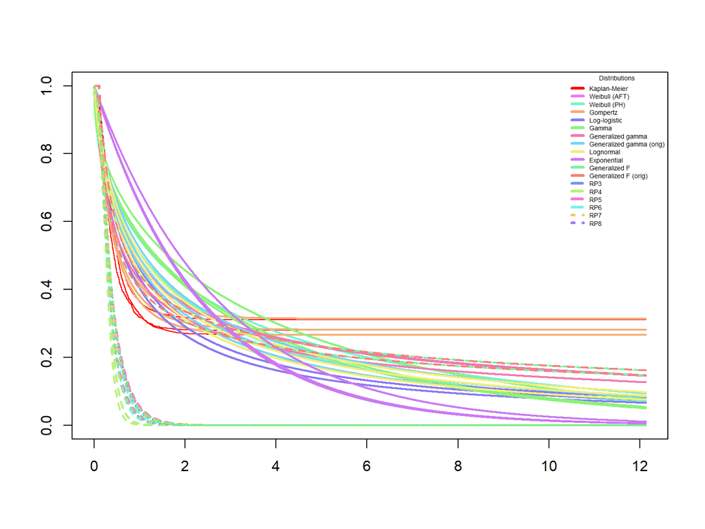

```r
get_distinct_hues <- function(ncolor,s=0.5,v=0.95,seed=2125) {
  golden_ratio_conjugate <- 0.618033988749895
  set.seed(seed)
  h <- runif(1)
  H <- vector("numeric",ncolor)
  for(i in seq_len(ncolor)) {
    h <- (h + golden_ratio_conjugate) %% 1
    H[i] <- h
  }
  hsv(H,s=s,v=v)
}

distinct_hues<-get_distinct_hues(18)
#rp02 no converge
plot(km.lc[[1]], col="red", conf.int=F);
   lines(fits_wei[[1]], col=distinct_hues[1], ci=F);
   lines(fits_weiph[[1]], col=distinct_hues[2], ci=F);
   lines(fits_gomp[[1]], col=distinct_hues[3], ci=F);
   lines(fits_llogis[[1]], col=distinct_hues[4], ci=F);#A0A36D
   lines(fits_gam[[1]], col=distinct_hues[5], ci=F);
   lines(fits_ggam[[1]], col=distinct_hues[6], ci=F);
   lines(fits_ggam_orig[[1]], col=distinct_hues[7], ci=F);
   lines(fits_logn[[1]], col=distinct_hues[8], ci=F);
   lines(fits_exp[[1]],col=distinct_hues[9], ci=F);
   lines(fits_genf[[1]],col=distinct_hues[10], ci=F, lty = 2);
   lines(fits_genf_orig[[1]],col=distinct_hues[11], ci=F, lty = 2);
  # lines(fits_rp02[[1]],col=distinct_hues[12], ci=F, lty = 2);
   lines(fits_rp03[[1]],col=distinct_hues[13], ci=F, lty = 2);
   lines(fits_rp04[[1]],col=distinct_hues[14], ci=F, lty = 2);
   lines(fits_rp05[[1]],col=distinct_hues[15], ci=F, lty = 2);
   lines(fits_rp06[[1]],col=distinct_hues[16], ci=F, lty = 2);
   lines(fits_rp07[[1]],col=distinct_hues[17], ci=F, lty = 3);
   lines(fits_rp08[[1]],col=distinct_hues[18], ci=F, lty = 3)

legend("topright", legend = c("Kaplan-Meier", "Weibull (AFT)", "Weibull (PH)","Gompertz", "Log-logistic", "Gamma",                 "Generalized gamma", "Generalized gamma (orig)", "Lognormal", "Exponential", "Generalized F","Generalized F (orig)", "RP3", "RP4", "RP5", "RP6", "RP7", "RP8"), col =
         c("red",distinct_hues),
       title = "Distributions", cex = .45, bty = "n", lty=c(rep(1,12),rep(2,4),rep(3,2)),lwd=3)# rep(3,4)
```

Time for this code chunk to run: 0.1 minutes

```r
fits_objects = c("fits_wei", "fits_weiph", "fits_gomp", "fits_llogis", "fits_gam", "fits_ggam", "fits_ggam_orig", "fits_logn", "fits_exp",  "fits_genf", "fits_genf_orig", "fits_rp02", "fits_rp03", "fits_rp04", "fits_rp05", "fits_rp06", "fits_rp07", "fits_rp08")

for( i in 1:length(setdiff(fits_objects,"fits_rp02"))){
    print(setdiff(fits_objects,"fits_rp02")[i])
    x<- get(setdiff(fits_objects,"fits_rp02")[i])
    x<-x[[1]]
    print(x$AIC)
}
```

```
[1] "fits_wei"
[1] 50183.62
[1] "fits_weiph"
[1] 50183.62
[1] "fits_gomp"
[1] 35043.79
[1] "fits_llogis"
[1] 44145.69
[1] "fits_gam"
[1] 53389.48
[1] "fits_ggam"
[1] 41339.6
[1] "fits_ggam_orig"
[1] 44903.69
[1] "fits_logn"
```

[output cut: 19 more lines]

Time for this code chunk to run: 0 minutes

```r
B_inter_flexsurv = 250
limit=500
#detach("package:flexsurv", unload=TRUE)
require(flexsurv)
vector <- c("con_quien_vive_joel_coup_chil", "con_quien_vive_joel_fam_or", "edad_al_ing_sc", "sexo_2",
            "escolaridad_rec", "sus_ini_mod_mvv", "freq_cons_sus_prin", "dg_trs_cons_sus_or",
            "sus_principal_mod", "cnt_mod_cie_10_or")
#_#_#_#_#_#_#_#_#_#_#_#_#_#_#_#_#_#_#_#_#_#_#_#_#_#_#_#_#_#_#_#_#_#_#_
set.seed(2125)
fits_c_gomp <-
flexsurvreg(formula=Surv(yrs_to_tr_dropout,  event) ~ con_quien_vive_joel_coup_chil+ con_quien_vive_joel_fam_or+  edad_al_ing_sc+ sexo_2+ escolaridad_rec+ sus_ini_mod_mvv+ freq_cons_sus_prin+ dg_trs_cons_sus_or+ sus_principal_mod+ cnt_mod_cie_10_or, data=prueba2_imp22, dist = "gompertz")#%>% slice(sample(1:nrow(prueba2_imp22),limit))

#_#_#_#_#_#_#_#_#_#_#_#_#_#_#_#_#_#_#_#_#_#_#_#_#_#_#_#_#_#_#_#_#_#_#_
#_#_#_#_#_#_#_#_#_#_#_#_#_#_#_#_#_#_#_#_#_#_#_#_#_#_#_#_#_#_#_#_#_#_#_
system.time(
ss.gomp.rmst_noboot <- standsurv(fits_c_gomp,
                type = "rmst",
                at = list(list(con_quien_vive_joel_coup_chil = 1),
                          list(con_quien_vive_joel_fam_or = 1),
                          list(con_quien_vive_joel_fam_or = 0, con_quien_vive_joel_coup_chil= 0)),
                t = seq(0,3,length=25),
                ci = TRUE,
                boot = FALSE,
                seed = 2125,
                contrast = "ratio"
))
```

```
   user  system elapsed
5140.29    2.87 5148.86
```

```r
system.time(
ss.gomp.surv_noboot <- standsurv(fits_c_gomp,
                type = "survival",
                at = list(list(con_quien_vive_joel_coup_chil = 1),
                          list(con_quien_vive_joel_fam_or = 1),
                          list(con_quien_vive_joel_fam_or = 0, con_quien_vive_joel_coup_chil= 0)),
                t = seq(0,3,length=25),
                ci = TRUE,
                boot = FALSE,
                seed = 2125,
                contrast = "ratio"
))
```

```
   user  system elapsed
 159.69    5.30  165.14
```

```r
system.time(
ss.gomp.rmst_noboot_diff <- standsurv(fits_c_gomp,
                type = "rmst",
                at = list(list(con_quien_vive_joel_coup_chil = 1),
                          list(con_quien_vive_joel_fam_or = 1),
                          list(con_quien_vive_joel_fam_or = 0, con_quien_vive_joel_coup_chil= 0)),
                t = seq(0,3,length=25),
                ci = TRUE,
                boot = FALSE,
                seed = 2125,
                contrast = "difference"
))
```

```
   user  system elapsed
5154.82    2.48 5163.52
```

```r
system.time(
ss.gomp.surv_noboot_diff <- standsurv(fits_c_gomp,
                type = "survival",
                at = list(list(con_quien_vive_joel_coup_chil = 1),
                          list(con_quien_vive_joel_fam_or = 1),
                          list(con_quien_vive_joel_fam_or = 0, con_quien_vive_joel_coup_chil= 0)),
                t = seq(0,3,length=25),
                ci = TRUE,
                boot = FALSE,
                seed = 2125,
                contrast = "difference"
))
```

```
   user  system elapsed
 173.44    2.13  175.83
```

```r
#_#_#_#_#_#_#_#_#_#_#_#_#_#_#_#_#_#_#_#_#_#_#_#_#_#_#_#_#_#_#_#_#_#_#_
#_#_#_#_#_#_#_#_#_#_#_#_#_#_#_#_#_#_#_#_#_#_#_#_#_#_#_#_#_#_#_#_#_#_#_
system.time(
ss.gomp.rmst_boot <- standsurv(fits_c_gomp,
                type = "rmst",
                at = list(list(con_quien_vive_joel_coup_chil = 1),
                          list(con_quien_vive_joel_fam_or = 1),
                          list(con_quien_vive_joel_fam_or = 0, con_quien_vive_joel_coup_chil= 0)),
                t = seq(0,3,length=25),
                ci = TRUE,
                boot = T,
                B = B_inter_flexsurv,
                seed = 2125,
                contrast = "ratio"
))
```

```
    user   system  elapsed
19495.84    10.19 19523.44
```

```r
system.time(
ss.gomp.surv_boot <- standsurv(fits_c_gomp,
                type = "survival",
                at = list(list(con_quien_vive_joel_coup_chil = 1),
                          list(con_quien_vive_joel_fam_or = 1),
                          list(con_quien_vive_joel_fam_or = 0, con_quien_vive_joel_coup_chil= 0)),
                t = seq(0,3,length=25),
                ci = TRUE,
                boot = T,
                B = B_inter_flexsurv,
                seed = 2125,
                contrast = "ratio"
))
```

```
   user  system elapsed
 443.10    2.59  445.89
```

```r
system.time(
ss.gomp.rmst_boot_diff <- standsurv(fits_c_gomp,
                type = "rmst",
                at = list(list(con_quien_vive_joel_coup_chil = 1),
                          list(con_quien_vive_joel_fam_or = 1),
                          list(con_quien_vive_joel_fam_or = 0, con_quien_vive_joel_coup_chil= 0)),
                t = seq(0,3,length=25),
                ci = TRUE,
                boot = T,
                B = B_inter_flexsurv,
                seed = 2125,
                contrast = "difference"
))
```

```
    user   system  elapsed
19310.14     8.58 19333.34
```

```r
system.time(
ss.gomp.surv_boot_diff <- standsurv(fits_c_gomp,
                type = "survival",
                at = list(list(con_quien_vive_joel_coup_chil = 1),
                          list(con_quien_vive_joel_fam_or = 1),
                          list(con_quien_vive_joel_fam_or = 0, con_quien_vive_joel_coup_chil= 0)),
                t = seq(0,3,length=25),
                ci = TRUE,
                boot = T,
                B = B_inter_flexsurv,
                seed = 2125,
                contrast = "difference"
))
```

```
   user  system elapsed
 441.14    2.27  443.78
```

```r
#no funciona  Error in eigen(Dmat) : infinite or missing values in 'x'
#flexsurvspline(formula=Surv(yrs_to_tr_dropout,  event) ~ con_quien_vive_joel_coup_chil+ con_quien_vive_joel_fam_or+  edad_al_ing_sc+ sexo_2+ escolaridad_rec+ sus_ini_mod_mvv+ freq_cons_sus_prin+ dg_trs_cons_sus_or+ sus_principal_mod+ cnt_mod_cie_10_or, k=5, data = prueba2_imp22[complete.cases(prueba2_imp22[,c(vector,"yrs_to_tr_dropout","event")]),] %>% dplyr::mutate(yrs_to_tr_dropout=ifelse(yrs_to_tr_dropout==0,.001,yrs_to_tr_dropout)) %>% data.frame(), control = list(fnscale = -14000))
#https://github.com/chjackson/flexsurv-dev/issues/69
set.seed(2125)
fits_c_rp04 <-
flexsurvspline(formula=Surv(yrs_to_tr_dropout,  event) ~ con_quien_vive_joel_coup_chil+ con_quien_vive_joel_fam_or+  edad_al_ing_sc+ sexo_2+ escolaridad_rec+ sus_ini_mod_mvv+ freq_cons_sus_prin+ dg_trs_cons_sus_or+ sus_principal_mod+ cnt_mod_cie_10_or, k=3, data = prueba2_imp22[complete.cases(prueba2_imp22[,c(vector,"yrs_to_tr_dropout","event")]),] %>% dplyr::mutate(yrs_to_tr_dropout=ifelse(yrs_to_tr_dropout==0,.001,yrs_to_tr_dropout)) %>% data.frame(), control = list(fnscale = -14000)) #%>% slice(sample(1:nrow(prueba2_imp22),(limit*10)))
#https://github.com/chjackson/flexsurv-dev/issues/69

#_#_#_#_#_#_#_#_#_#_#_#_#_#_#_#_#_#_#_#_#_#_#_#_#_#_#_#_#_#_#_#_#_#_#_
#_#_#_#_#_#_#_#_#_#_#_#_#_#_#_#_#_#_#_#_#_#_#_#_#_#_#_#_#_#_#_#_#_#_#_
system.time(
ss.rp04.rmst_noboot <- standsurv(fits_c_rp04,
                type = "rmst",
                at = list(list(con_quien_vive_joel_coup_chil = 1),
                          list(con_quien_vive_joel_fam_or = 1),
                          list(con_quien_vive_joel_fam_or = 0, con_quien_vive_joel_coup_chil= 0)),
                t = seq(0,3,length=25),
                ci = TRUE,
                boot = FALSE,
                seed = 2125,
                contrast = "ratio"
))
```

```
    user   system  elapsed
47882.49    15.24 47933.11
```

```r
system.time(
ss.rp04.surv_noboot <- standsurv(fits_c_rp04,
                type = "survival",
                at = list(list(con_quien_vive_joel_coup_chil = 1),
                          list(con_quien_vive_joel_fam_or = 1),
                          list(con_quien_vive_joel_fam_or = 0, con_quien_vive_joel_coup_chil= 0)),
                t = seq(0,3,length=25),
                ci = TRUE,
                boot = FALSE,
                seed = 2125,
                contrast = "ratio"
))
```

```
   user  system elapsed
 210.78    4.01  215.39
```

```r
system.time(
ss.rp04.rmst_noboot_diff <- standsurv(fits_c_rp04,
                type = "rmst",
                at = list(list(con_quien_vive_joel_coup_chil = 1),
                          list(con_quien_vive_joel_fam_or = 1),
                          list(con_quien_vive_joel_fam_or = 0, con_quien_vive_joel_coup_chil= 0)),
                t = seq(0,3,length=25),
                ci = TRUE,
                boot = FALSE,
                seed = 2125,
                contrast = "difference"
))
```

```
    user   system  elapsed
48085.92    17.08 48172.92
```

```r
system.time(
ss.rp04.surv_noboot_diff <- standsurv(fits_c_rp04,
                type = "survival",
                at = list(list(con_quien_vive_joel_coup_chil = 1),
                          list(con_quien_vive_joel_fam_or = 1),
                          list(con_quien_vive_joel_fam_or = 0, con_quien_vive_joel_coup_chil= 0)),
                t = seq(0,3,length=25),
                ci = TRUE,
                boot = FALSE,
                seed = 2125,
                contrast = "difference"
))
```

```
   user  system elapsed
 213.94    1.19  215.38
```

```r
#_#_#_#_#_#_#_#_#_#_#_#_#_#_#_#_#_#_#_#_#_#_#_#_#_#_#_#_#_#_#_#_#_#_#_
#_#_#_#_#_#_#_#_#_#_#_#_#_#_#_#_#_#_#_#_#_#_#_#_#_#_#_#_#_#_#_#_#_#_#_
system.time(
ss.rp04.rmst_boot <- standsurv(fits_c_rp04,
                type = "rmst",
                at = list(list(con_quien_vive_joel_coup_chil = 1),
                          list(con_quien_vive_joel_fam_or = 1),
                          list(con_quien_vive_joel_fam_or = 0, con_quien_vive_joel_coup_chil= 0)),
                t = seq(0,3,length=25),
                ci = TRUE,
                boot = T,
                B = B_inter_flexsurv,
                seed = 2125,
                contrast = "ratio"
))
```

```
     user    system   elapsed
169975.91     51.78 170140.53
```

```r
system.time(
ss.rp04.surv_boot <- standsurv(fits_c_rp04,
                type = "survival",
                at = list(list(con_quien_vive_joel_coup_chil = 1),
                          list(con_quien_vive_joel_fam_or = 1),
                          list(con_quien_vive_joel_fam_or = 0, con_quien_vive_joel_coup_chil= 0)),
                t = seq(0,3,length=25),
                ci = TRUE,
                boot = T,
                B = B_inter_flexsurv,
                seed = 2125,
                contrast = "ratio"
))
```

```
   user  system elapsed
3016.66    4.43 3023.67
```

```r
system.time(
ss.rp04.rmst_boot_diff <- standsurv(fits_c_rp04,
                type = "rmst",
                at = list(list(con_quien_vive_joel_coup_chil = 1),
                          list(con_quien_vive_joel_fam_or = 1),
                          list(con_quien_vive_joel_fam_or = 0, con_quien_vive_joel_coup_chil= 0)),
                t = seq(0,3,length=25),
                ci = TRUE,
                boot = T,
                B = B_inter_flexsurv,
                seed = 2125,
                contrast = "difference"
))
```

```
     user    system   elapsed
172055.80     61.48 172289.22
```

```r
system.time(
ss.rp04.surv_boot_diff <- standsurv(fits_c_rp04,
                type = "survival",
                at = list(list(con_quien_vive_joel_coup_chil = 1),
                          list(con_quien_vive_joel_fam_or = 1),
                          list(con_quien_vive_joel_fam_or = 0, con_quien_vive_joel_coup_chil= 0)),
                t = seq(0,3,length=25),
                ci = TRUE,
                boot = T,
                B = B_inter_flexsurv,
                seed = 2125,
                contrast = "difference"
))
```

```
   user  system elapsed
3063.64    4.97 3072.59
```

```r
#_#_#_#_#_#_#_#_#_#_#_#_#_#_#_#_#_#_#_#_#_#_#_#_#_#_#_#_#_#_#_#_#_#_#_
#_#_#_#_#_#_#_#_#_#_#_#_#_#_#_#_#_#_#_#_#_#_#_#_#_#_#_#_#_#_#_#_#_#_#_
```

Time for this code chunk to run: 0.1 minutes

### RMSTs, flexsurv, Gompertz

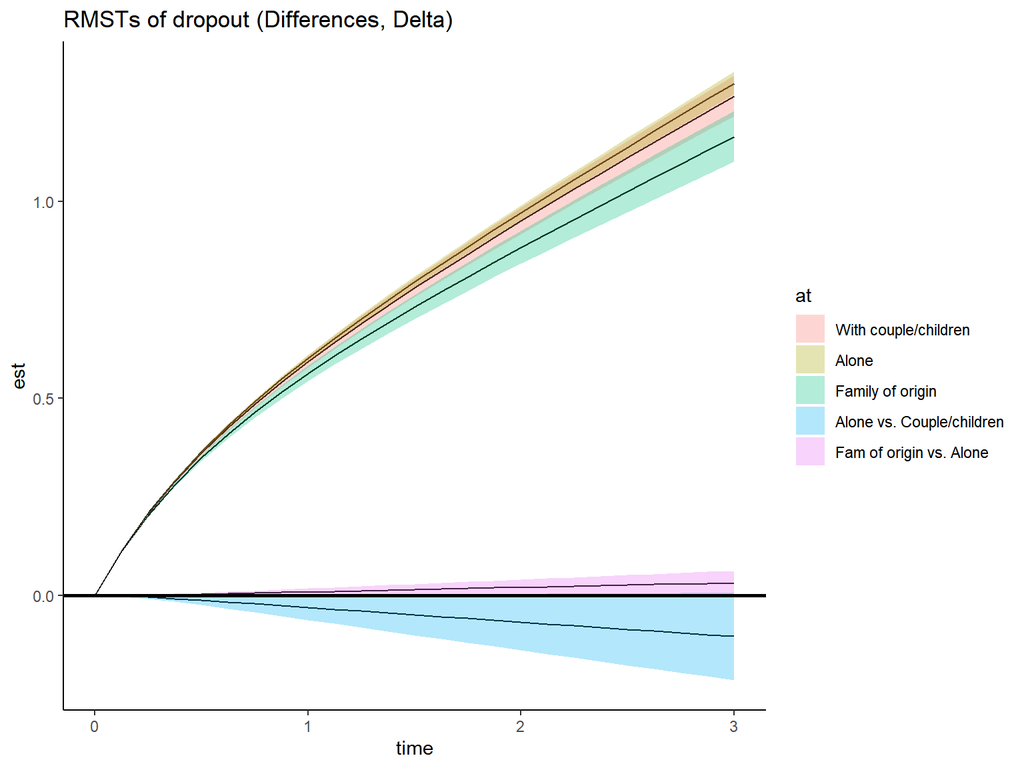

```r
invisible("RMSTs")
ss.gomp.rmst_noboot_diff %>%
  dplyr::rename_with(~ paste0(.x, "_est"), .cols =  names(.)[!str_ends(names(.), "time|_lci|_uci")]) %>%
  dplyr::rename_with(~ sub("2_1","21",.x), .cols =  names(.)[grepl("2_1",names(.))]) %>%
  dplyr::rename_with(~ sub("3_1","31",.x), .cols =  names(.)[grepl("3_1",names(.))]) %>%
  pivot_longer(!time, names_to=c("at","est"), names_sep="_", values_to="rmst") %>%
  pivot_wider(id_cols=c("time", "at"), names_from="est", values_from="rmst") %>%
  dplyr::mutate(at=factor(at, levels=c(paste0("at",1:3),paste0("contrast",3:2,"1")), labels=c("With couple/children", "Alone", "Family of origin", "Alone vs. Couple/children","Fam of origin vs. Alone"))) %>%
  ggplot()+
  geom_line(aes(x=time, y=est, fill=at))+
  geom_ribbon(aes(x=time, ymin=lci, ymax=uci, fill=at), alpha=.3)+
  geom_hline(aes(yintercept=0), linewidth=1)+
  theme_classic()+
  ggtitle("RMSTs of dropout (Differences, Delta)")
```

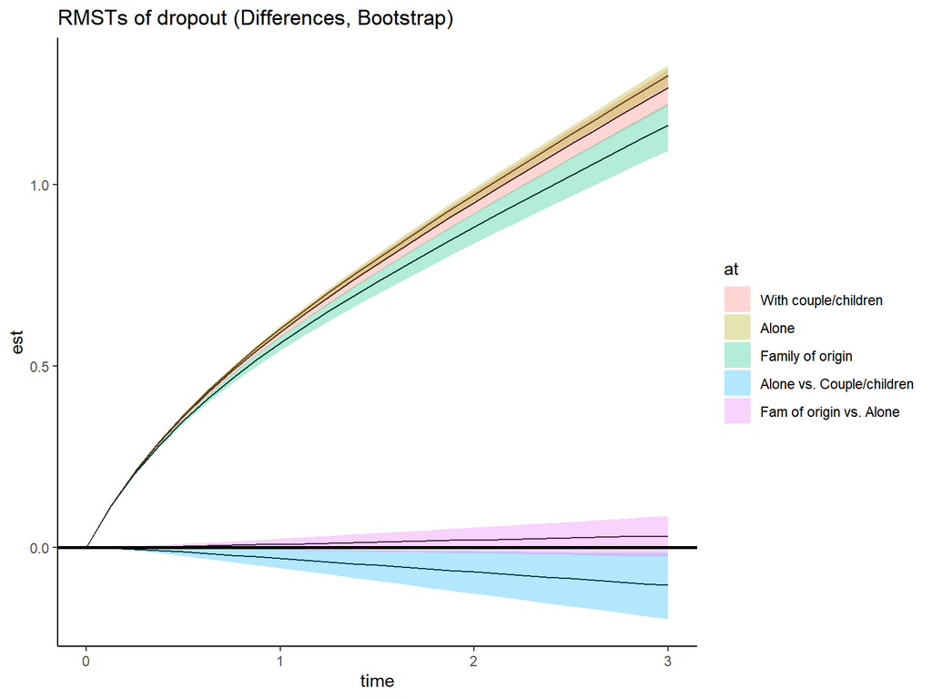

```r
ss.gomp.rmst_boot_diff %>%
  dplyr::rename_with(~ paste0(.x, "_est"), .cols =  names(.)[!str_ends(names(.), "time|_lci|_uci")]) %>%
  dplyr::rename_with(~ sub("2_1","21",.x), .cols =  names(.)[grepl("2_1",names(.))]) %>%
  dplyr::rename_with(~ sub("3_1","31",.x), .cols =  names(.)[grepl("3_1",names(.))]) %>%
  pivot_longer(!time, names_to=c("at","est"), names_sep="_", values_to="rmst") %>%
  pivot_wider(id_cols=c("time", "at"), names_from="est", values_from="rmst") %>%
  dplyr::mutate(at=factor(at, levels=c(paste0("at",1:3),paste0("contrast",3:2,"1")), labels=c("With couple/children", "Alone", "Family of origin", "Alone vs. Couple/children","Fam of origin vs. Alone"))) %>%
  ggplot()+
  geom_line(aes(x=time, y=est, fill=at))+
  geom_ribbon(aes(x=time, ymin=lci, ymax=uci, fill=at), alpha=.3)+
  geom_hline(aes(yintercept=0), linewidth=1)+
  theme_classic()+
  ggtitle("RMSTs of dropout (Differences, Bootstrap)")
```

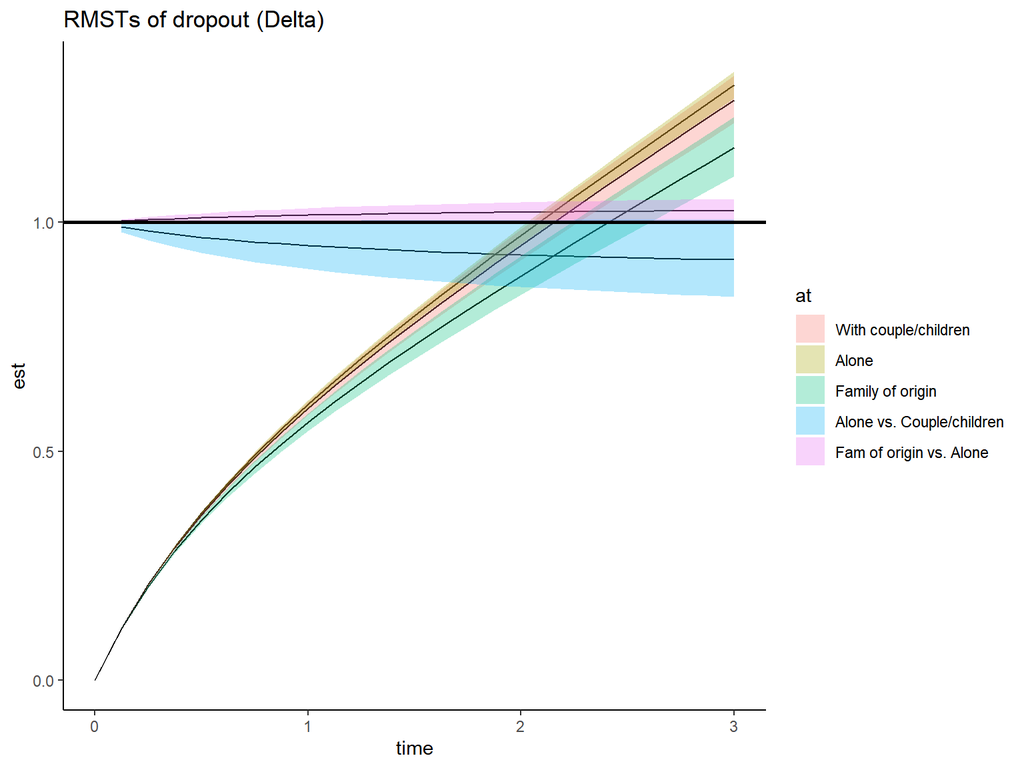

```r
ss.gomp.rmst_noboot %>%
  dplyr::rename_with(~ paste0(.x, "_est"), .cols =  names(.)[!str_ends(names(.), "time|_lci|_uci")]) %>%
  dplyr::rename_with(~ sub("2_1","21",.x), .cols =  names(.)[grepl("2_1",names(.))]) %>%
  dplyr::rename_with(~ sub("3_1","31",.x), .cols =  names(.)[grepl("3_1",names(.))]) %>%
  pivot_longer(!time, names_to=c("at","est"), names_sep="_", values_to="rmst") %>%
  pivot_wider(id_cols=c("time", "at"), names_from="est", values_from="rmst") %>%
  dplyr::mutate(at=factor(at, levels=c(paste0("at",1:3),paste0("contrast",3:2,"1")), labels=c("With couple/children", "Alone", "Family of origin", "Alone vs. Couple/children","Fam of origin vs. Alone"))) %>%
  ggplot()+
  geom_line(aes(x=time, y=est, fill=at))+
  geom_ribbon(aes(x=time, ymin=lci, ymax=uci, fill=at), alpha=.3)+
  geom_hline(aes(yintercept=1), linewidth=1)+
  theme_classic()+
  ggtitle("RMSTs of dropout (Delta)")
```

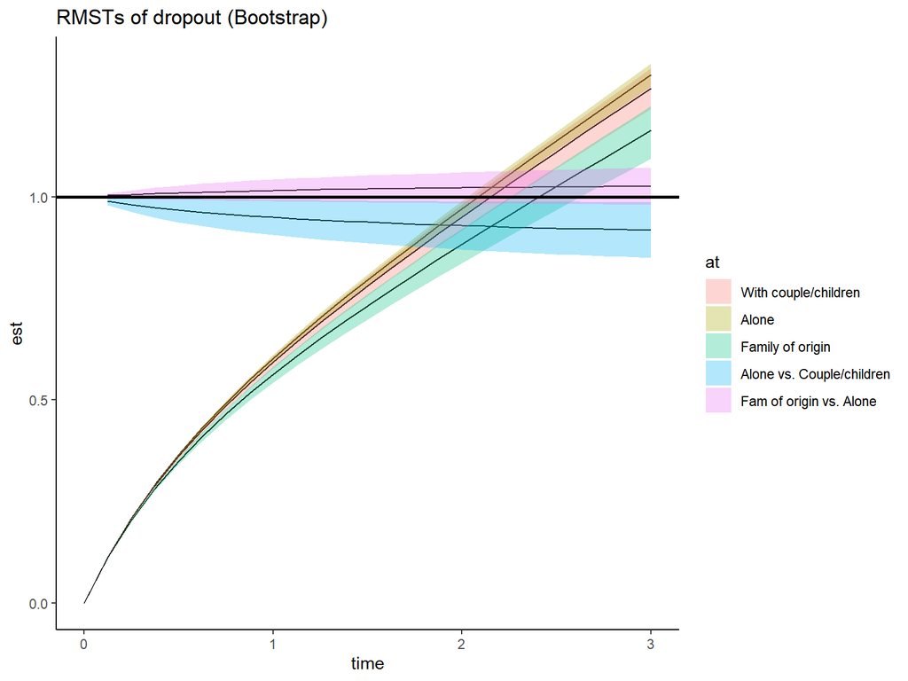

```r
ss.gomp.rmst_boot %>%
  dplyr::rename_with(~ paste0(.x, "_est"), .cols =  names(.)[!str_ends(names(.), "time|_lci|_uci")]) %>%
  dplyr::rename_with(~ sub("2_1","21",.x), .cols =  names(.)[grepl("2_1",names(.))]) %>%
  dplyr::rename_with(~ sub("3_1","31",.x), .cols =  names(.)[grepl("3_1",names(.))]) %>%
  pivot_longer(!time, names_to=c("at","est"), names_sep="_", values_to="rmst") %>%
  pivot_wider(id_cols=c("time", "at"), names_from="est", values_from="rmst") %>%
  dplyr::mutate(at=factor(at, levels=c(paste0("at",1:3),paste0("contrast",3:2,"1")), labels=c("With couple/children", "Alone", "Family of origin", "Alone vs. Couple/children","Fam of origin vs. Alone"))) %>%
  ggplot()+
  geom_line(aes(x=time, y=est, fill=at))+
  geom_ribbon(aes(x=time, ymin=lci, ymax=uci, fill=at), alpha=.3)+
  geom_hline(aes(yintercept=1), linewidth=1)+
  theme_classic()+
ggtitle("RMSTs of dropout (Bootstrap)")
```

Time for this code chunk to run: 0.1 minutes

### Surv, flexsurv, Gompertz

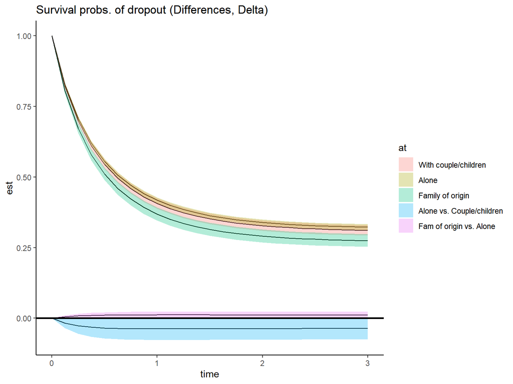

```r
ss.gomp.surv_noboot_diff %>%
  dplyr::rename_with(~ paste0(.x, "_est"), .cols =  names(.)[!str_ends(names(.), "time|_lci|_uci")]) %>%
  dplyr::rename_with(~ sub("2_1","21",.x), .cols =  names(.)[grepl("2_1",names(.))]) %>%
  dplyr::rename_with(~ sub("3_1","31",.x), .cols =  names(.)[grepl("3_1",names(.))]) %>%
  pivot_longer(!time, names_to=c("at","est"), names_sep="_", values_to="rmst") %>%
  pivot_wider(id_cols=c("time", "at"), names_from="est", values_from="rmst") %>%
  dplyr::mutate(at=factor(at, levels=c(paste0("at",1:3),paste0("contrast",3:2,"1")), labels=c("With couple/children", "Alone", "Family of origin", "Alone vs. Couple/children","Fam of origin vs. Alone"))) %>%
  ggplot()+
  geom_line(aes(x=time, y=est, fill=at))+
  geom_ribbon(aes(x=time, ymin=lci, ymax=uci, fill=at), alpha=.3)+
  geom_hline(aes(yintercept=0), linewidth=1)+
  theme_classic()+
  ggtitle("Survival probs. of dropout (Differences, Delta)")
```

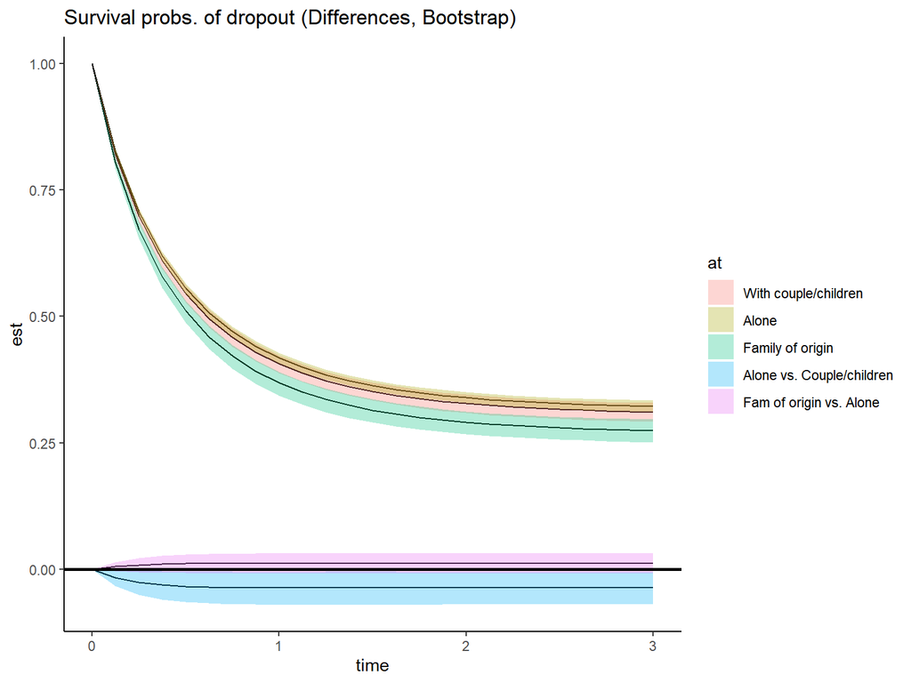

```r
ss.gomp.surv_boot_diff %>%
  dplyr::rename_with(~ paste0(.x, "_est"), .cols =  names(.)[!str_ends(names(.), "time|_lci|_uci")]) %>%
  dplyr::rename_with(~ sub("2_1","21",.x), .cols =  names(.)[grepl("2_1",names(.))]) %>%
  dplyr::rename_with(~ sub("3_1","31",.x), .cols =  names(.)[grepl("3_1",names(.))]) %>%
  pivot_longer(!time, names_to=c("at","est"), names_sep="_", values_to="rmst") %>%
  pivot_wider(id_cols=c("time", "at"), names_from="est", values_from="rmst") %>%
  dplyr::mutate(at=factor(at, levels=c(paste0("at",1:3),paste0("contrast",3:2,"1")), labels=c("With couple/children", "Alone", "Family of origin", "Alone vs. Couple/children","Fam of origin vs. Alone"))) %>%
  ggplot()+
  geom_line(aes(x=time, y=est, fill=at))+
  geom_ribbon(aes(x=time, ymin=lci, ymax=uci, fill=at), alpha=.3)+
  geom_hline(aes(yintercept=0), linewidth=1)+
  theme_classic()+
  ggtitle("Survival probs. of dropout (Differences, Bootstrap)")
```

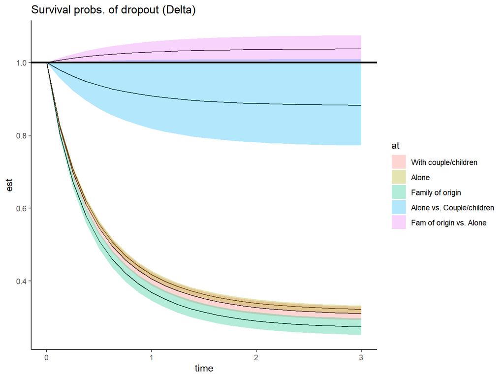

```r
ss.gomp.surv_noboot %>%
  dplyr::rename_with(~ paste0(.x, "_est"), .cols =  names(.)[!str_ends(names(.), "time|_lci|_uci")]) %>%
  dplyr::rename_with(~ sub("2_1","21",.x), .cols =  names(.)[grepl("2_1",names(.))]) %>%
  dplyr::rename_with(~ sub("3_1","31",.x), .cols =  names(.)[grepl("3_1",names(.))]) %>%
  pivot_longer(!time, names_to=c("at","est"), names_sep="_", values_to="rmst") %>%
  pivot_wider(id_cols=c("time", "at"), names_from="est", values_from="rmst") %>%
  dplyr::mutate(at=factor(at, levels=c(paste0("at",1:3),paste0("contrast",3:2,"1")), labels=c("With couple/children", "Alone", "Family of origin", "Alone vs. Couple/children","Fam of origin vs. Alone"))) %>%
  ggplot()+
  geom_line(aes(x=time, y=est, fill=at))+
  geom_ribbon(aes(x=time, ymin=lci, ymax=uci, fill=at), alpha=.3)+
  geom_hline(aes(yintercept=1), linewidth=1)+
  theme_classic()+
  ggtitle("Survival probs. of dropout (Delta)")
```

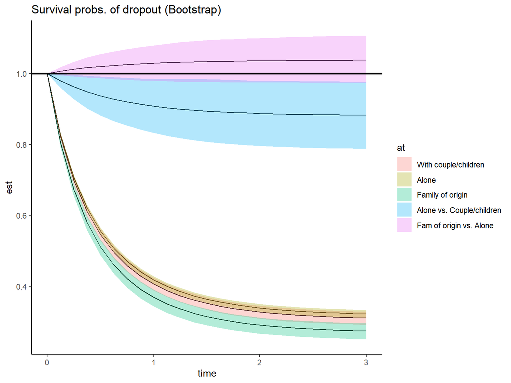

```r
ss.gomp.surv_boot %>%
  dplyr::rename_with(~ paste0(.x, "_est"), .cols =  names(.)[!str_ends(names(.), "time|_lci|_uci")]) %>%
  dplyr::rename_with(~ sub("2_1","21",.x), .cols =  names(.)[grepl("2_1",names(.))]) %>%
  dplyr::rename_with(~ sub("3_1","31",.x), .cols =  names(.)[grepl("3_1",names(.))]) %>%
  pivot_longer(!time, names_to=c("at","est"), names_sep="_", values_to="rmst") %>%
  pivot_wider(id_cols=c("time", "at"), names_from="est", values_from="rmst") %>%
  dplyr::mutate(at=factor(at, levels=c(paste0("at",1:3),paste0("contrast",3:2,"1")), labels=c("With couple/children", "Alone", "Family of origin", "Alone vs. Couple/children","Fam of origin vs. Alone"))) %>%
  ggplot()+
  geom_line(aes(x=time, y=est, fill=at))+
  geom_ribbon(aes(x=time, ymin=lci, ymax=uci, fill=at), alpha=.3)+
  geom_hline(aes(yintercept=1), linewidth=1)+
  theme_classic()+
  ggtitle("Survival probs. of dropout (Bootstrap)")
```

Time for this code chunk to run: 0 minutes

### RMSTs, flexsurv, RP04

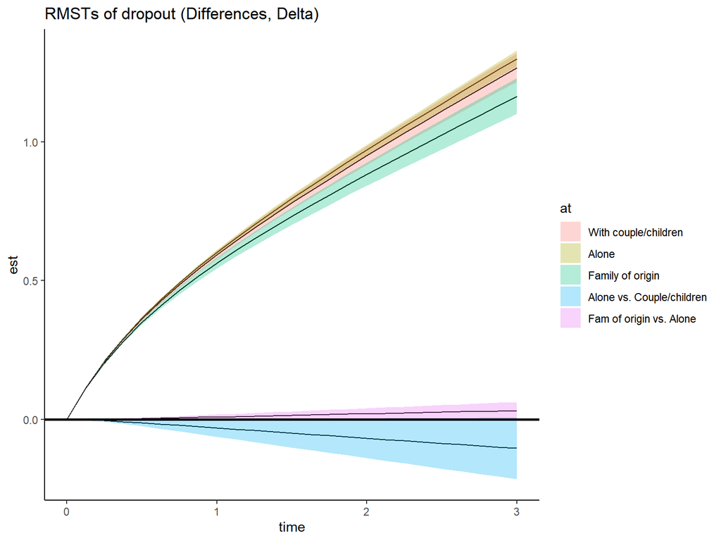

```r
invisible("RMSTs")
ss.gomp.rmst_noboot_diff %>%
  dplyr::rename_with(~ paste0(.x, "_est"), .cols =  names(.)[!str_ends(names(.), "time|_lci|_uci")]) %>%
  dplyr::rename_with(~ sub("2_1","21",.x), .cols =  names(.)[grepl("2_1",names(.))]) %>%
  dplyr::rename_with(~ sub("3_1","31",.x), .cols =  names(.)[grepl("3_1",names(.))]) %>%
  pivot_longer(!time, names_to=c("at","est"), names_sep="_", values_to="rmst") %>%
  pivot_wider(id_cols=c("time", "at"), names_from="est", values_from="rmst") %>%
  dplyr::mutate(at=factor(at, levels=c(paste0("at",1:3),paste0("contrast",3:2,"1")), labels=c("With couple/children", "Alone", "Family of origin", "Alone vs. Couple/children","Fam of origin vs. Alone"))) %>%
  ggplot()+
  geom_line(aes(x=time, y=est, fill=at))+
  geom_ribbon(aes(x=time, ymin=lci, ymax=uci, fill=at), alpha=.3)+
  geom_hline(aes(yintercept=0), linewidth=1)+
  theme_classic()+
  ggtitle("RMSTs of dropout (Differences, Delta)")
```

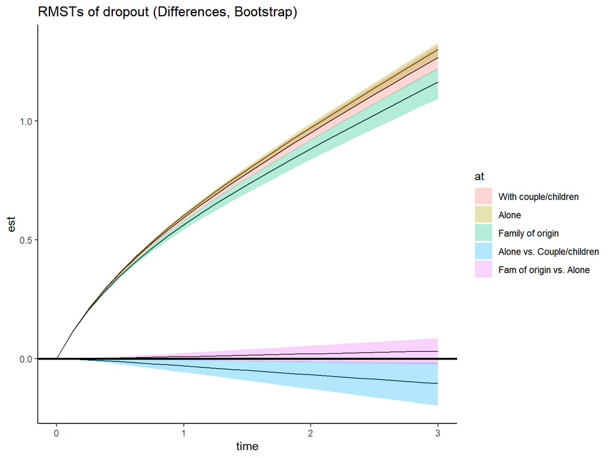

```r
ss.gomp.rmst_boot_diff %>%
  dplyr::rename_with(~ paste0(.x, "_est"), .cols =  names(.)[!str_ends(names(.), "time|_lci|_uci")]) %>%
  dplyr::rename_with(~ sub("2_1","21",.x), .cols =  names(.)[grepl("2_1",names(.))]) %>%
  dplyr::rename_with(~ sub("3_1","31",.x), .cols =  names(.)[grepl("3_1",names(.))]) %>%
  pivot_longer(!time, names_to=c("at","est"), names_sep="_", values_to="rmst") %>%
  pivot_wider(id_cols=c("time", "at"), names_from="est", values_from="rmst") %>%
  dplyr::mutate(at=factor(at, levels=c(paste0("at",1:3),paste0("contrast",3:2,"1")), labels=c("With couple/children", "Alone", "Family of origin", "Alone vs. Couple/children","Fam of origin vs. Alone"))) %>%
  ggplot()+
  geom_line(aes(x=time, y=est, fill=at))+
  geom_ribbon(aes(x=time, ymin=lci, ymax=uci, fill=at), alpha=.3)+
  geom_hline(aes(yintercept=0), linewidth=1)+
  theme_classic()+
  ggtitle("RMSTs of dropout (Differences, Bootstrap)")
```

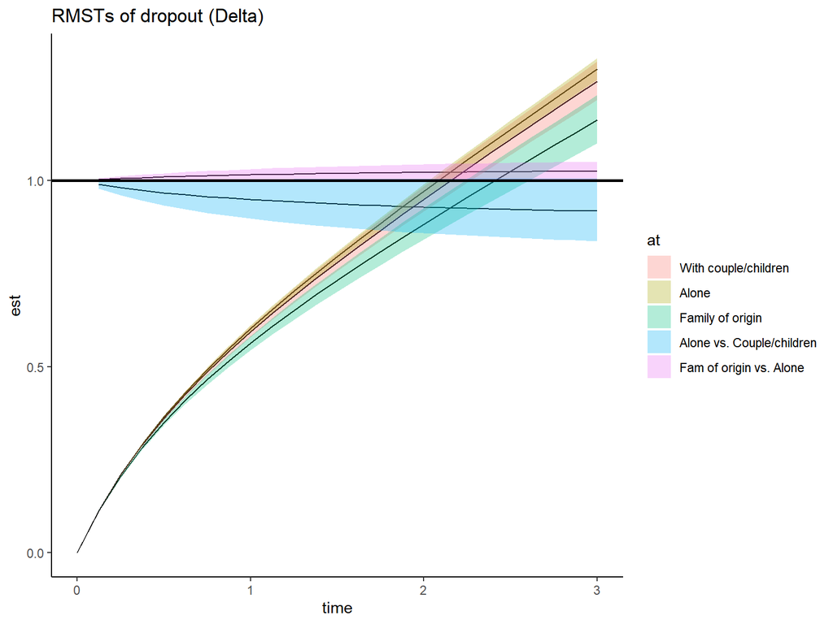

```r
ss.gomp.rmst_noboot %>%
  dplyr::rename_with(~ paste0(.x, "_est"), .cols =  names(.)[!str_ends(names(.), "time|_lci|_uci")]) %>%
  dplyr::rename_with(~ sub("2_1","21",.x), .cols =  names(.)[grepl("2_1",names(.))]) %>%
  dplyr::rename_with(~ sub("3_1","31",.x), .cols =  names(.)[grepl("3_1",names(.))]) %>%
  pivot_longer(!time, names_to=c("at","est"), names_sep="_", values_to="rmst") %>%
  pivot_wider(id_cols=c("time", "at"), names_from="est", values_from="rmst") %>%
  dplyr::mutate(at=factor(at, levels=c(paste0("at",1:3),paste0("contrast",3:2,"1")), labels=c("With couple/children", "Alone", "Family of origin", "Alone vs. Couple/children","Fam of origin vs. Alone"))) %>%
  ggplot()+
  geom_line(aes(x=time, y=est, fill=at))+
  geom_ribbon(aes(x=time, ymin=lci, ymax=uci, fill=at), alpha=.3)+
  geom_hline(aes(yintercept=1), linewidth=1)+
  theme_classic()+
  ggtitle("RMSTs of dropout (Delta)")
```

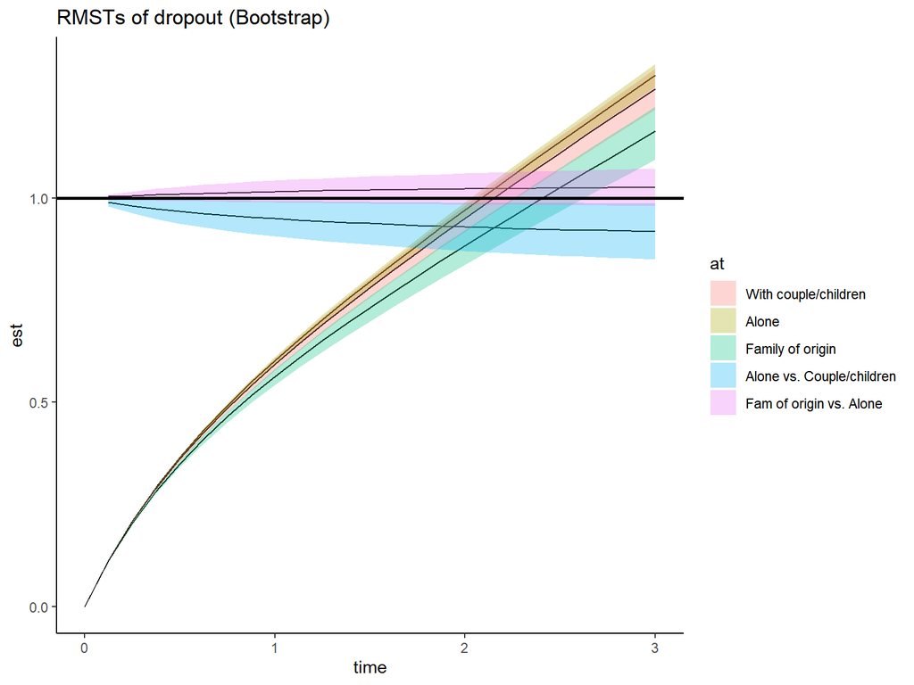

```r
ss.gomp.rmst_boot %>%
  dplyr::rename_with(~ paste0(.x, "_est"), .cols =  names(.)[!str_ends(names(.), "time|_lci|_uci")]) %>%
  dplyr::rename_with(~ sub("2_1","21",.x), .cols =  names(.)[grepl("2_1",names(.))]) %>%
  dplyr::rename_with(~ sub("3_1","31",.x), .cols =  names(.)[grepl("3_1",names(.))]) %>%
  pivot_longer(!time, names_to=c("at","est"), names_sep="_", values_to="rmst") %>%
  pivot_wider(id_cols=c("time", "at"), names_from="est", values_from="rmst") %>%
  dplyr::mutate(at=factor(at, levels=c(paste0("at",1:3),paste0("contrast",3:2,"1")), labels=c("With couple/children", "Alone", "Family of origin", "Alone vs. Couple/children","Fam of origin vs. Alone"))) %>%
  ggplot()+
  geom_line(aes(x=time, y=est, fill=at))+
  geom_ribbon(aes(x=time, ymin=lci, ymax=uci, fill=at), alpha=.3)+
  geom_hline(aes(yintercept=1), linewidth=1)+
  theme_classic()+
ggtitle("RMSTs of dropout (Bootstrap)")
```

Time for this code chunk to run: 0.1 minutes

### Surv, flexsurv, RP04

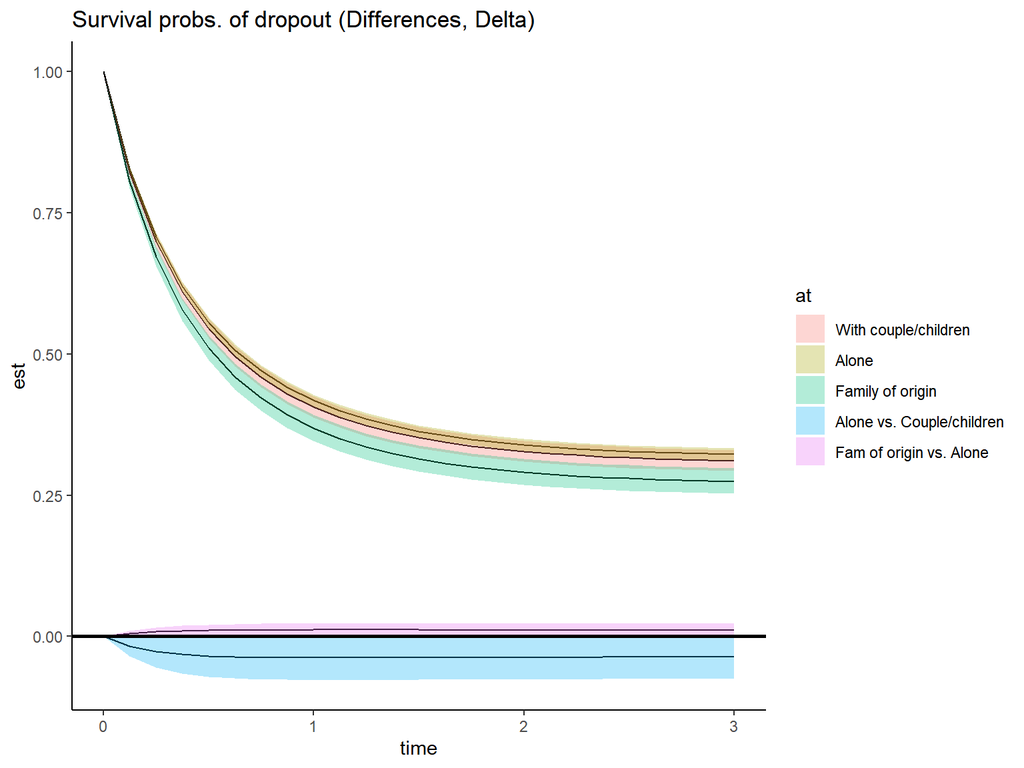

```r
ss.gomp.surv_noboot_diff %>%
  dplyr::rename_with(~ paste0(.x, "_est"), .cols =  names(.)[!str_ends(names(.), "time|_lci|_uci")]) %>%
  dplyr::rename_with(~ sub("2_1","21",.x), .cols =  names(.)[grepl("2_1",names(.))]) %>%
  dplyr::rename_with(~ sub("3_1","31",.x), .cols =  names(.)[grepl("3_1",names(.))]) %>%
  pivot_longer(!time, names_to=c("at","est"), names_sep="_", values_to="rmst") %>%
  pivot_wider(id_cols=c("time", "at"), names_from="est", values_from="rmst") %>%
  dplyr::mutate(at=factor(at, levels=c(paste0("at",1:3),paste0("contrast",3:2,"1")), labels=c("With couple/children", "Alone", "Family of origin", "Alone vs. Couple/children","Fam of origin vs. Alone"))) %>%
  ggplot()+
  geom_line(aes(x=time, y=est, fill=at))+
  geom_ribbon(aes(x=time, ymin=lci, ymax=uci, fill=at), alpha=.3)+
  geom_hline(aes(yintercept=0), linewidth=1)+
  theme_classic()+
  ggtitle("Survival probs. of dropout (Differences, Delta)")
```

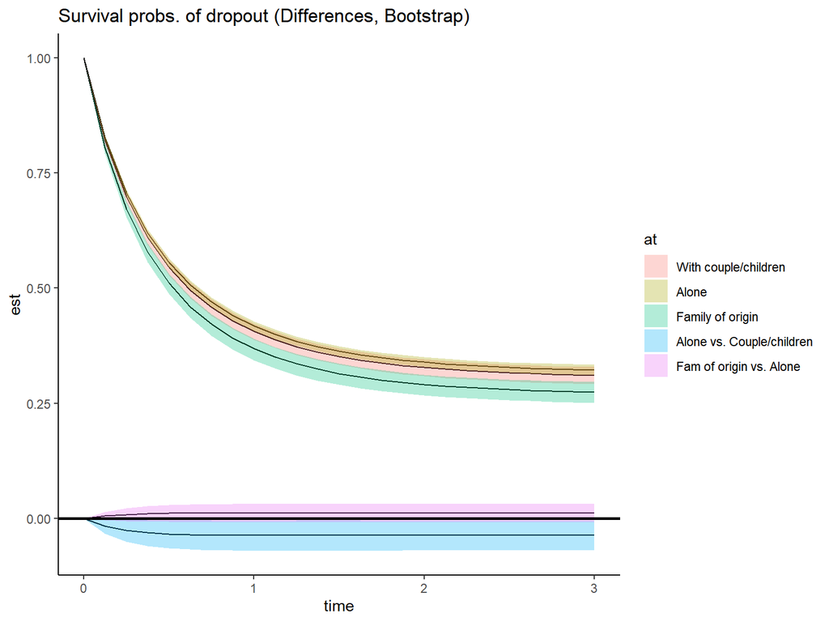

```r
ss.gomp.surv_boot_diff %>%
  dplyr::rename_with(~ paste0(.x, "_est"), .cols =  names(.)[!str_ends(names(.), "time|_lci|_uci")]) %>%
  dplyr::rename_with(~ sub("2_1","21",.x), .cols =  names(.)[grepl("2_1",names(.))]) %>%
  dplyr::rename_with(~ sub("3_1","31",.x), .cols =  names(.)[grepl("3_1",names(.))]) %>%
  pivot_longer(!time, names_to=c("at","est"), names_sep="_", values_to="rmst") %>%
  pivot_wider(id_cols=c("time", "at"), names_from="est", values_from="rmst") %>%
  dplyr::mutate(at=factor(at, levels=c(paste0("at",1:3),paste0("contrast",3:2,"1")), labels=c("With couple/children", "Alone", "Family of origin", "Alone vs. Couple/children","Fam of origin vs. Alone"))) %>%
  ggplot()+
  geom_line(aes(x=time, y=est, fill=at))+
  geom_ribbon(aes(x=time, ymin=lci, ymax=uci, fill=at), alpha=.3)+
  geom_hline(aes(yintercept=0), linewidth=1)+
  theme_classic()+
  ggtitle("Survival probs. of dropout (Differences, Bootstrap)")
```

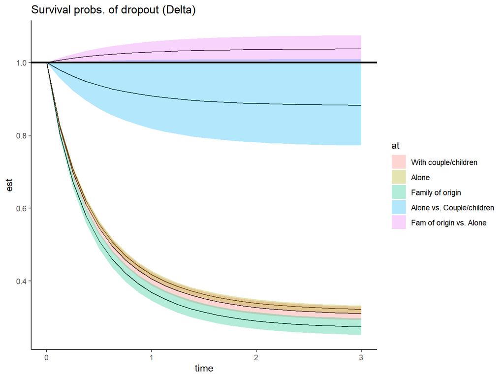

```r
ss.gomp.surv_noboot %>%
  dplyr::rename_with(~ paste0(.x, "_est"), .cols =  names(.)[!str_ends(names(.), "time|_lci|_uci")]) %>%
  dplyr::rename_with(~ sub("2_1","21",.x), .cols =  names(.)[grepl("2_1",names(.))]) %>%
  dplyr::rename_with(~ sub("3_1","31",.x), .cols =  names(.)[grepl("3_1",names(.))]) %>%
  pivot_longer(!time, names_to=c("at","est"), names_sep="_", values_to="rmst") %>%
  pivot_wider(id_cols=c("time", "at"), names_from="est", values_from="rmst") %>%
  dplyr::mutate(at=factor(at, levels=c(paste0("at",1:3),paste0("contrast",3:2,"1")), labels=c("With couple/children", "Alone", "Family of origin", "Alone vs. Couple/children","Fam of origin vs. Alone"))) %>%
  ggplot()+
  geom_line(aes(x=time, y=est, fill=at))+
  geom_ribbon(aes(x=time, ymin=lci, ymax=uci, fill=at), alpha=.3)+
  geom_hline(aes(yintercept=1), linewidth=1)+
  theme_classic()+
  ggtitle("Survival probs. of dropout (Delta)")
```

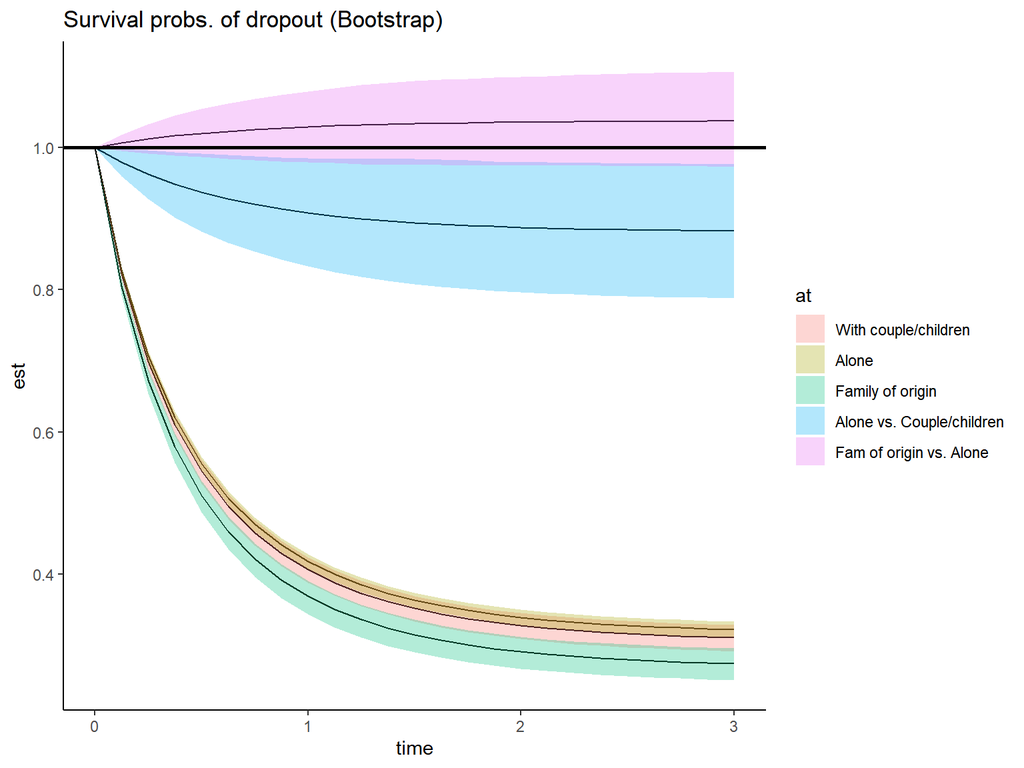

```r
ss.gomp.surv_boot %>%
  dplyr::rename_with(~ paste0(.x, "_est"), .cols =  names(.)[!str_ends(names(.), "time|_lci|_uci")]) %>%
  dplyr::rename_with(~ sub("2_1","21",.x), .cols =  names(.)[grepl("2_1",names(.))]) %>%
  dplyr::rename_with(~ sub("3_1","31",.x), .cols =  names(.)[grepl("3_1",names(.))]) %>%
  pivot_longer(!time, names_to=c("at","est"), names_sep="_", values_to="rmst") %>%
  pivot_wider(id_cols=c("time", "at"), names_from="est", values_from="rmst") %>%
  dplyr::mutate(at=factor(at, levels=c(paste0("at",1:3),paste0("contrast",3:2,"1")), labels=c("With couple/children", "Alone", "Family of origin", "Alone vs. Couple/children","Fam of origin vs. Alone"))) %>%
  ggplot()+
  geom_line(aes(x=time, y=est, fill=at))+
  geom_ribbon(aes(x=time, ymin=lci, ymax=uci, fill=at), alpha=.3)+
  geom_hline(aes(yintercept=1), linewidth=1)+
  theme_classic()+
  ggtitle("Survival probs. of dropout (Bootstrap)")
```

Time for this code chunk to run: 0.1 minutes

# Inverse probability weighted Kaplan-meier

```r
require(landest)
km_alone_t05<-
surv.iptw.km(tl=prueba2_imp22$yrs_to_tr_dropout[which(prueba2_imp22$con_quien_vive_joel=="Alone")], dl = prueba2_imp22$event[which(prueba2_imp22$con_quien_vive_joel=="Alone")], tt=.5, ps.weights = prueba2_imp22$weight_mult_a00[which(prueba2_imp22$con_quien_vive_joel=="Alone")], conf.int=T)

km_alone_t1<-
surv.iptw.km(tl=prueba2_imp22$yrs_to_tr_dropout[which(prueba2_imp22$con_quien_vive_joel=="Alone")], dl = prueba2_imp22$event[which(prueba2_imp22$con_quien_vive_joel=="Alone")], tt=1, ps.weights = prueba2_imp22$weight_mult_a00[which(prueba2_imp22$con_quien_vive_joel=="Alone")], conf.int=T)

km_alone_t3<-
surv.iptw.km(tl=prueba2_imp22$yrs_to_tr_dropout[which(prueba2_imp22$con_quien_vive_joel=="Alone")], dl = prueba2_imp22$event[which(prueba2_imp22$con_quien_vive_joel=="Alone")], tt=3, ps.weights = prueba2_imp22$weight_mult_a00[which(prueba2_imp22$con_quien_vive_joel=="Alone")], conf.int=T)




km_famorigin_t05<-
surv.iptw.km(tl=prueba2_imp22$yrs_to_tr_dropout[which(prueba2_imp22$con_quien_vive_joel=="Family of origin")], dl = prueba2_imp22$event[which(prueba2_imp22$con_quien_vive_joel=="Family of origin")], tt=.5, ps.weights = prueba2_imp22$weight_mult_a00[which(prueba2_imp22$con_quien_vive_joel=="Family of origin")], conf.int=T)

km_famorigin_t1<-
surv.iptw.km(tl=prueba2_imp22$yrs_to_tr_dropout[which(prueba2_imp22$con_quien_vive_joel=="Family of origin")], dl = prueba2_imp22$event[which(prueba2_imp22$con_quien_vive_joel=="Family of origin")], tt=1, ps.weights = prueba2_imp22$weight_mult_a00[which(prueba2_imp22$con_quien_vive_joel=="Family of origin")], conf.int=T)

km_famorigin_t3<-
surv.iptw.km(tl=prueba2_imp22$yrs_to_tr_dropout[which(prueba2_imp22$con_quien_vive_joel=="Family of origin")], dl = prueba2_imp22$event[which(prueba2_imp22$con_quien_vive_joel=="Family of origin")], tt=3, ps.weights = prueba2_imp22$weight_mult_a00[which(prueba2_imp22$con_quien_vive_joel=="Family of origin")], conf.int=T)





km_coupchil_t05<-
surv.iptw.km(tl=prueba2_imp22$yrs_to_tr_dropout[which(prueba2_imp22$con_quien_vive_joel=="With couple/children")], dl = prueba2_imp22$event[which(prueba2_imp22$con_quien_vive_joel=="With couple/children")], tt=.5, ps.weights = prueba2_imp22$weight_mult_a00[which(prueba2_imp22$con_quien_vive_joel=="With couple/children")], conf.int=T)

km_coupchil_t1<-
surv.iptw.km(tl=prueba2_imp22$yrs_to_tr_dropout[which(prueba2_imp22$con_quien_vive_joel=="With couple/children")], dl = prueba2_imp22$event[which(prueba2_imp22$con_quien_vive_joel=="With couple/children")], tt=1, ps.weights = prueba2_imp22$weight_mult_a00[which(prueba2_imp22$con_quien_vive_joel=="With couple/children")], conf.int=T)

km_coupchil_t3<-
surv.iptw.km(tl=prueba2_imp22$yrs_to_tr_dropout[which(prueba2_imp22$con_quien_vive_joel=="With couple/children")], dl = prueba2_imp22$event[which(prueba2_imp22$con_quien_vive_joel=="With couple/children")], tt=3,  ps.weights = prueba2_imp22$weight_mult_a00[which(prueba2_imp22$con_quien_vive_joel=="With couple/children")], conf.int=T)







km2_alone_t05<-
surv.iptw.km(tl=prueba2_imp22$yrs_to_tr_dropout[which(prueba2_imp22$con_quien_vive_joel=="Alone")], dl = prueba2_imp22$event[which(prueba2_imp22$con_quien_vive_joel=="Alone")], tt=.5, ps.weights = prueba2_imp22$weight_mult_a0[which(prueba2_imp22$con_quien_vive_joel=="Alone")], conf.int=T)

km2_alone_t1<-
surv.iptw.km(tl=prueba2_imp22$yrs_to_tr_dropout[which(prueba2_imp22$con_quien_vive_joel=="Alone")], dl = prueba2_imp22$event[which(prueba2_imp22$con_quien_vive_joel=="Alone")], tt=1, ps.weights = prueba2_imp22$weight_mult_a0[which(prueba2_imp22$con_quien_vive_joel=="Alone")], conf.int=T)

km2_alone_t3<-
surv.iptw.km(tl=prueba2_imp22$yrs_to_tr_dropout[which(prueba2_imp22$con_quien_vive_joel=="Alone")], dl = prueba2_imp22$event[which(prueba2_imp22$con_quien_vive_joel=="Alone")], tt=3, ps.weights = prueba2_imp22$weight_mult_a0[which(prueba2_imp22$con_quien_vive_joel=="Alone")], conf.int=T)




km2_famorigin_t05<-
surv.iptw.km(tl=prueba2_imp22$yrs_to_tr_dropout[which(prueba2_imp22$con_quien_vive_joel=="Family of origin")], dl = prueba2_imp22$event[which(prueba2_imp22$con_quien_vive_joel=="Family of origin")], tt=.5, ps.weights = prueba2_imp22$weight_mult_a0[which(prueba2_imp22$con_quien_vive_joel=="Family of origin")], conf.int=T)

km2_famorigin_t1<-
surv.iptw.km(tl=prueba2_imp22$yrs_to_tr_dropout[which(prueba2_imp22$con_quien_vive_joel=="Family of origin")], dl = prueba2_imp22$event[which(prueba2_imp22$con_quien_vive_joel=="Family of origin")], tt=1, ps.weights = prueba2_imp22$weight_mult_a0[which(prueba2_imp22$con_quien_vive_joel=="Family of origin")], conf.int=T)

km2_famorigin_t3<-
surv.iptw.km(tl=prueba2_imp22$yrs_to_tr_dropout[which(prueba2_imp22$con_quien_vive_joel=="Family of origin")], dl = prueba2_imp22$event[which(prueba2_imp22$con_quien_vive_joel=="Family of origin")], tt=3, ps.weights = prueba2_imp22$weight_mult_a0[which(prueba2_imp22$con_quien_vive_joel=="Family of origin")], conf.int=T)





km2_coupchil_t05<-
surv.iptw.km(tl=prueba2_imp22$yrs_to_tr_dropout[which(prueba2_imp22$con_quien_vive_joel=="With couple/children")], dl = prueba2_imp22$event[which(prueba2_imp22$con_quien_vive_joel=="With couple/children")], tt=.5, ps.weights = prueba2_imp22$weight_mult_a0[which(prueba2_imp22$con_quien_vive_joel=="With couple/children")], conf.int=T)

km2_coupchil_t1<-
surv.iptw.km(tl=prueba2_imp22$yrs_to_tr_dropout[which(prueba2_imp22$con_quien_vive_joel=="With couple/children")], dl = prueba2_imp22$event[which(prueba2_imp22$con_quien_vive_joel=="With couple/children")], tt=1, ps.weights = prueba2_imp22$weight_mult_a0[which(prueba2_imp22$con_quien_vive_joel=="With couple/children")], conf.int=T)

km2_coupchil_t3<-
surv.iptw.km(tl=prueba2_imp22$yrs_to_tr_dropout[which(prueba2_imp22$con_quien_vive_joel=="With couple/children")], dl = prueba2_imp22$event[which(prueba2_imp22$con_quien_vive_joel=="With couple/children")], tt=3,  ps.weights = prueba2_imp22$weight_mult_a0[which(prueba2_imp22$con_quien_vive_joel=="With couple/children")], conf.int=T)


get_est <- function(mat_res){
    LCI <- mat_res$conf.int.normal.S[[1]]
  mean <- mat_res$S.estimate
  UCI <- mat_res$conf.int.normal.S[[2]]
  mean_CI <- cbind.data.frame(mean, LCI, UCI)
  return(mean_CI)
}

#km2_alone_t05 km2_alone_t1  km2_alone_t3 km2_famorigin_t05 km2_famorigin_t1 km2_famorigin_t3 km2_coupchil_t05 km2_coupchil_t1 km2_coupchil_t3
get_est_km_noboot_05_3<- #cbind.data.frame(group="",time="",mean="",LCI="",UCI=""),
rbind.data.frame(cbind.data.frame(group="Alone", time="0.5", get_est(km_alone_t05)),
                 cbind.data.frame(group="Alone", time="1", get_est(km_alone_t1)),
                 cbind.data.frame(group="Alone", time="3", get_est(km_alone_t3)),
                 cbind.data.frame(group="Family of origin", time="0.5", get_est(km_famorigin_t05)),
                 cbind.data.frame(group="Family of origin", time="1", get_est(km_famorigin_t1)),
                 cbind.data.frame(group="Family of origin", time="3", get_est(km_famorigin_t3)),
                 cbind.data.frame(group="With couple/children", time="0.5", get_est(km_coupchil_t05)),
                 cbind.data.frame(group="With couple/children", time="1", get_est(km_coupchil_t1)),
                 cbind.data.frame(group="With couple/children", time="3", get_est(km_coupchil_t3))
                  )

get_est2_km_noboot_05_3<- #cbind.data.frame(group="",time="",mean="",LCI="",UCI=""),
rbind.data.frame(cbind.data.frame(group="Alone", time="0.5", get_est(km2_alone_t05)),
                 cbind.data.frame(group="Alone", time="1", get_est(km2_alone_t1)),
                 cbind.data.frame(group="Alone", time="3", get_est(km2_alone_t3)),
                 cbind.data.frame(group="Family of origin", time="0.5", get_est(km2_famorigin_t05)),
                 cbind.data.frame(group="Family of origin", time="1", get_est(km2_famorigin_t1)),
                 cbind.data.frame(group="Family of origin", time="3", get_est(km2_famorigin_t3)),
                 cbind.data.frame(group="With couple/children", time="0.5", get_est(km2_coupchil_t05)),
                 cbind.data.frame(group="With couple/children", time="1", get_est(km2_coupchil_t1)),
                 cbind.data.frame(group="With couple/children", time="3", get_est(km2_coupchil_t3))
                  )

get_est_km_noboot_05_3 %>%
  #dplyr::mutate_if(c("mean", "LCI", "UCI"),~round(readr::parse_number(.,2)) %>%
  knitr::kable("markdown", digits=2, caption="Kaplan meier (IPW Multinomial logistic), Survival Estimates (95%CI no bootstrap)")
```

Table 3: Kaplan meier (IPW Multinomial logistic), Survival Estimates (95%CI no bootstrap)

| group | time | mean | LCI | UCI |
| --- | --- | --- | --- | --- |
| Alone | 0.5 | 0.46 | 0.43 | 0.49 |
| Alone | 1 | 0.32 | 0.29 | 0.35 |
| Alone | 3 | 0.28 | 0.26 | 0.31 |
| Family of origin | 0.5 | 0.53 | 0.52 | 0.53 |
| Family of origin | 1 | 0.36 | 0.35 | 0.37 |
| Family of origin | 3 | 0.31 | 0.30 | 0.32 |
| With couple/children | 0.5 | 0.49 | 0.48 | 0.50 |
| With couple/children | 1 | 0.32 | 0.30 | 0.33 |
| With couple/children | 3 | 0.26 | 0.25 | 0.27 |

Time for this code chunk to run: 0.1 minutes

```r
get_est2_km_noboot_05_3 %>%
  #dplyr::mutate_if(c("mean", "LCI", "UCI"),~round(readr::parse_number(.,2)) %>%
  knitr::kable("markdown", digits=2, caption="Kaplan meier (IPW BART), Survival Estimates (95%CI no bootstrap)")
```

Table 4: Kaplan meier (IPW BART), Survival Estimates (95%CI no bootstrap)

| group | time | mean | LCI | UCI |
| --- | --- | --- | --- | --- |
| Alone | 0.5 | 0.46 | 0.43 | 0.49 |
| Alone | 1 | 0.32 | 0.29 | 0.35 |
| Alone | 3 | 0.28 | 0.25 | 0.31 |
| Family of origin | 0.5 | 0.53 | 0.52 | 0.54 |
| Family of origin | 1 | 0.36 | 0.35 | 0.37 |
| Family of origin | 3 | 0.31 | 0.30 | 0.32 |
| With couple/children | 0.5 | 0.49 | 0.47 | 0.50 |
| With couple/children | 1 | 0.31 | 0.30 | 0.33 |
| With couple/children | 3 | 0.26 | 0.25 | 0.27 |

```r
#knitr::kable(digits=2) %>%   kableExtra::kable_classic()
```

Time for this code chunk to run: 0 minutes

## Multinomial logistic

```r
require(boot)

B_iter <- 2000

invisible("Alone")
kmfit05alone <- function(data, i){
      dat <- dplyr::mutate(data[i,], yrs_to_tr_dropout= dplyr::case_when(yrs_to_tr_dropout==0~ 0.0001, T~yrs_to_tr_dropout))
      set.seed(2125)
      kmlist<-list()
      design_weights <- survey::svydesign(ids = ~1, data = dat, weights = ~weight_mult_a00)

      s<-survey::svykm(Surv(time=yrs_to_tr_dropout,event=event)~con_quien_vive_joel, se=F,
                  #con_quien_vive_joel,
                  design=design_weights, rho=0, gamma=0)

      kmlist<-cbind(s$Alone$time,s$Alone$surv) %>% as_tibble() %>% dplyr::filter(V1>0.49 & V1<0.51) %>% summarise(mean=mean(V2)) %>% unlist()
      return(kmlist)
}
set.seed(2125)
bootapp05alone <- boot(data = prueba2_imp22, statistic = kmfit05alone, R = B_iter)

kmfit1alone <- function(data, i){
      dat <- dplyr::mutate(data[i,], yrs_to_tr_dropout= dplyr::case_when(yrs_to_tr_dropout==0~ 0.0001, T~yrs_to_tr_dropout))
      set.seed(2125)
      kmlist<-list()
      design_weights <- survey::svydesign(ids = ~1, data = dat, weights = ~weight_mult_a00)

      s<-survey::svykm(Surv(time=yrs_to_tr_dropout,event=event)~con_quien_vive_joel, se=F,
                  #con_quien_vive_joel,
                  design=design_weights, rho=0, gamma=0)

      kmlist<-cbind(s$Alone$time,s$Alone$surv) %>% as_tibble() %>% dplyr::filter(V1>0.9 & V1<1.1) %>% summarise(mean=mean(V2)) %>% unlist()
      return(kmlist)
}
set.seed(2125)
bootapp1alone <- boot(data = prueba2_imp22, statistic = kmfit1alone, R = B_iter)

kmfit3alone <- function(data, i){
      dat <- dplyr::mutate(data[i,], yrs_to_tr_dropout= dplyr::case_when(yrs_to_tr_dropout==0~ 0.0001, T~yrs_to_tr_dropout))
      set.seed(2125)
      kmlist<-list()
      design_weights <- survey::svydesign(ids = ~1, data = dat, weights = ~weight_mult_a00)

      s<-survey::svykm(Surv(time=yrs_to_tr_dropout,event=event)~con_quien_vive_joel, se=F,
                  #con_quien_vive_joel,
                  design=design_weights, rho=0, gamma=0)

      kmlist<-cbind(s$Alone$time,s$Alone$surv) %>% as_tibble() %>% dplyr::filter(V1>2.9 & V1<3.1) %>% summarise(mean=mean(V2)) %>% unlist()
      return(kmlist)
}
set.seed(2125)
bootapp3alone <- boot(data = prueba2_imp22, statistic = kmfit3alone, R = B_iter)


invisible("Family of origin")

kmfit05fam <- function(data, i){
      dat <- dplyr::mutate(data[i,], yrs_to_tr_dropout= dplyr::case_when(yrs_to_tr_dropout==0~ 0.0001, T~yrs_to_tr_dropout))
      set.seed(2125)
      kmlist<-list()
      design_weights <- survey::svydesign(ids = ~1, data = dat, weights = ~weight_mult_a00)

      s<-survey::svykm(Surv(time=yrs_to_tr_dropout,event=event)~con_quien_vive_joel, se=F,
                  #con_quien_vive_joel,
                  design=design_weights, rho=0, gamma=0)

      kmlist<-cbind(s$`Family of origin`$time,s$`Family of origin`$surv) %>% as_tibble() %>% dplyr::filter(V1>0.49 & V1<0.51) %>% summarise(mean=mean(V2)) %>% unlist()
      return(kmlist)
}
set.seed(2125)
bootapp05fam <- boot(data = prueba2_imp22, statistic = kmfit05fam, R = B_iter)

kmfit1fam <- function(data, i){
      dat <- dplyr::mutate(data[i,], yrs_to_tr_dropout= dplyr::case_when(yrs_to_tr_dropout==0~ 0.0001, T~yrs_to_tr_dropout))
      set.seed(2125)
      kmlist<-list()
      design_weights <- survey::svydesign(ids = ~1, data = dat, weights = ~weight_mult_a00)

      s<-survey::svykm(Surv(time=yrs_to_tr_dropout,event=event)~con_quien_vive_joel, se=F,
                  #con_quien_vive_joel,
                  design=design_weights, rho=0, gamma=0)

      kmlist<-cbind(s$`Family of origin`$time,s$`Family of origin`$surv) %>% as_tibble() %>% dplyr::filter(V1>0.9 & V1<1.1) %>% summarise(mean=mean(V2)) %>% unlist()
      return(kmlist)
}
set.seed(2125)
bootapp1fam <- boot(data = prueba2_imp22, statistic = kmfit1fam, R = B_iter)

kmfit3fam <- function(data, i){
      dat <- dplyr::mutate(data[i,], yrs_to_tr_dropout= dplyr::case_when(yrs_to_tr_dropout==0~ 0.0001, T~yrs_to_tr_dropout))
      set.seed(2125)
      kmlist<-list()
      design_weights <- survey::svydesign(ids = ~1, data = dat, weights = ~weight_mult_a00)

      s<-survey::svykm(Surv(time=yrs_to_tr_dropout,event=event)~con_quien_vive_joel, se=F,
                  #con_quien_vive_joel,
                  design=design_weights, rho=0, gamma=0)

      kmlist<-cbind(s$`Family of origin`$time,s$`Family of origin`$surv) %>% as_tibble() %>% dplyr::filter(V1>2.9 & V1<3.1) %>% summarise(mean=mean(V2)) %>% unlist()
      return(kmlist)
}
set.seed(2125)
bootapp3fam <- boot(data = prueba2_imp22, statistic = kmfit3fam, R = B_iter)


invisible("Couple & children")

kmfit05coupchil <- function(data, i){
      dat <- dplyr::mutate(data[i,], yrs_to_tr_dropout= dplyr::case_when(yrs_to_tr_dropout==0~ 0.0001, T~yrs_to_tr_dropout))
      set.seed(2125)
      kmlist<-list()
      design_weights <- survey::svydesign(ids = ~1, data = dat, weights = ~weight_mult_a00)

      s<-survey::svykm(Surv(time=yrs_to_tr_dropout,event=event)~con_quien_vive_joel, se=F,
                  #con_quien_vive_joel,
                  design=design_weights, rho=0, gamma=0)

      kmlist<-cbind(s$`With couple/children`$time,s$`With couple/children`$surv) %>% as_tibble() %>% dplyr::filter(V1>0.49 & V1<0.51) %>% summarise(mean=mean(V2)) %>% unlist()
      return(kmlist)
}
set.seed(2125)
bootapp05coupchil <- boot(data = prueba2_imp22, statistic = kmfit05coupchil, R = B_iter)

kmfit1coupchil <- function(data, i){
      dat <- dplyr::mutate(data[i,], yrs_to_tr_dropout= dplyr::case_when(yrs_to_tr_dropout==0~ 0.0001, T~yrs_to_tr_dropout))
      set.seed(2125)
      kmlist<-list()
      design_weights <- survey::svydesign(ids = ~1, data = dat, weights = ~weight_mult_a00)

      s<-survey::svykm(Surv(time=yrs_to_tr_dropout,event=event)~con_quien_vive_joel, se=F,
                  #con_quien_vive_joel,
                  design=design_weights, rho=0, gamma=0)

      kmlist<-cbind(s$`With couple/children`$time,s$`With couple/children`$surv) %>% as_tibble() %>% dplyr::filter(V1>0.9 & V1<1.1) %>% summarise(mean=mean(V2)) %>% unlist()
      return(kmlist)
}
set.seed(2125)
bootapp1coupchil <- boot(data = prueba2_imp22, statistic = kmfit1coupchil, R = B_iter)

kmfit3coupchil <- function(data, i){
      dat <- dplyr::mutate(data[i,], yrs_to_tr_dropout= dplyr::case_when(yrs_to_tr_dropout==0~ 0.0001, T~yrs_to_tr_dropout))
      set.seed(2125)
      kmlist<-list()
      design_weights <- survey::svydesign(ids = ~1, data = dat, weights = ~weight_mult_a00)

      s<-survey::svykm(Surv(time=yrs_to_tr_dropout,event=event)~con_quien_vive_joel, se=F,
                  #con_quien_vive_joel,
                  design=design_weights, rho=0, gamma=0)

      kmlist<-cbind(s$`With couple/children`$time,s$`With couple/children`$surv) %>% as_tibble() %>% dplyr::filter(V1>2.9 & V1<3.1) %>% summarise(mean=mean(V2)) %>% unlist()
      return(kmlist)
}
set.seed(2125)
bootapp3coupchil <- boot(data = prueba2_imp22, statistic = kmfit3coupchil, R = B_iter)


#_#_#_#_#_#_#_#_#_#_#_#_#_#_#_#_#_#_#_#_#_#_#_#_#_#_#_#_#_#_#_#_#_#_#_#_#_#_#_#_#_#_#_#_#_#_#_#_
#_#_#_#_#_#_#_#_#_#_#_#_#_#_#_#_#_#_#_#_#_#_#_#_#_#_#_#_#_#_#_#_#_#_#_#_#_#_#_#_#_#_#_#_#_#_#_#_

#Función para obtener intervalos de confianza al 95% del remuestreo
get_estimation<-function(mat_res){
  LCI <- (boot.ci(mat_res, type = "basic"))[[4]][[4]]
  mean <- as.numeric((boot.ci(mat_res, type = "basic"))[[2]])
  UCI <- (boot.ci(mat_res, type = "basic"))[[4]][[5]]
  mean_CI <- cbind.data.frame(mean, LCI, UCI)
  return(mean_CI)
}

# invisible("replicate times")
# design_weights <- survey::svydesign(ids = ~1, data = dplyr::mutate(prueba2_imp22, yrs_to_tr_dropout= dplyr::case_when(yrs_to_tr_dropout==0~ 0.0001, T~yrs_to_tr_dropout)), weights = ~weight_mult_a00)
# z<-survey::svykm(Surv(time=yrs_to_tr_dropout,event=event)~con_quien_vive_joel, design=design_weights , rho=0, gamma=0)

get_est_km_05_3<-
rbind.data.frame(cbind.data.frame(group="Alone", time="0.5", get_estimation(bootapp05alone)),
                 cbind.data.frame(group="Alone", time="1", get_estimation(bootapp1alone)),
                 cbind.data.frame(group="Alone", time="3", get_estimation(bootapp3alone)),
                 cbind.data.frame(group="Family of origin", time="0.5", get_estimation(bootapp05fam)),
                 cbind.data.frame(group="Family of origin", time="1", get_estimation(bootapp1fam)),
                 cbind.data.frame(group="Family of origin", time="3", get_estimation(bootapp3fam)),
                 cbind.data.frame(group="With couple/children", time="0.5", get_estimation(bootapp05coupchil)),
                 cbind.data.frame(group="With couple/children", time="1", get_estimation(bootapp1coupchil)),
                 cbind.data.frame(group="With couple/children", time="3", get_estimation(bootapp3coupchil))
                  )

get_est_km_05_3 %>%
  knitr::kable("markdown", digits=2, caption="Kaplan meier (IPW Multinomial logistic), Survival Estimates (Bootstrap 95%CI)")
```

Table 5: Kaplan meier (IPW Multinomial logistic), Survival Estimates (Bootstrap 95%CI)

| group | time | mean | LCI | UCI |
| --- | --- | --- | --- | --- |
| Alone | 0.5 | 0.46 | 0.43 | 0.49 |
| Alone | 1 | 0.32 | 0.29 | 0.35 |
| Alone | 3 | 0.28 | 0.25 | 0.31 |
| Family of origin | 0.5 | 0.53 | 0.52 | 0.54 |
| Family of origin | 1 | 0.36 | 0.36 | 0.37 |
| Family of origin | 3 | 0.31 | 0.30 | 0.32 |
| With couple/children | 0.5 | 0.49 | 0.47 | 0.50 |
| With couple/children | 1 | 0.32 | 0.30 | 0.33 |
| With couple/children | 3 | 0.26 | 0.25 | 0.27 |

Time for this code chunk to run: 0.9 minutes